# 每个程序员都应该了解的内存知识

# What Every Programmer Should Know About Memory

Ulrich Drepper  
Red Hat, Inc.  
drepper@redhat.com  
2007年11月21日

Ulrich Drepper  
Red Hat, Inc.  
drepper@redhat.com  
November 21, 2007

## 摘要

## Abstract

随着CPU内核变得越来越快、数量越来越多，对大多数程序而言，限制性因素现在是、并且在今后一段时间内仍将是内存访问。硬件设计者们提出了越来越复杂的内存处理和加速技术——例如CPU缓存——但如果没有程序员的一些帮助，这些技术就无法以最佳方式工作。遗憾的是，大多数程序员既不太了解计算机内存子系统或CPU缓存的结构，也不太了解使用它们的代价。本文解释了现代通用硬件上所使用的内存子系统的结构，说明了CPU缓存为何被开发出来、它们如何工作，以及程序应当怎样做才能通过利用它们来获得最佳性能。

As CPU cores become both faster and more numerous, the limiting factor for most programs is now, and will be for some time, memory access. Hardware designers have come up with ever more sophisticated memory handling and acceleration techniques–such as CPU caches–but these cannot work optimally without some help from the programmer. Unfortunately, neither the structure nor the cost of using the memory subsystem of a computer or the caches on CPUs is well understood by most programmers. This paper explains the structure of memory subsystems in use on modern commodity hardware, illustrating why CPU caches were developed, how they work, and what programs should do to achieve optimal performance by utilizing them.

## 1 引言

## 1 Introduction

早期的计算机要简单得多。系统的各个组件，例如CPU、内存、大容量存储器和网络接口，是共同开发的，因此它们的性能相当均衡。例如，内存和网络接口提供数据的速度并不比CPU（快多少）。

In the early days computers were much simpler. The various components of a system, such as the CPU, memory, mass storage, and network interfaces, were developed together and, as a result, were quite balanced in their performance. For example, the memory and network interfaces were not (much) faster than the CPU at providing data.

一旦计算机的基本结构稳定下来，硬件开发者开始专注于优化各个子系统，这种情况就改变了。突然之间，计算机某些组件的性能大幅落后，瓶颈随之出现。大容量存储器和内存子系统尤其如此，出于成本原因，它们相对于其他组件改进得更慢。

This situation changed once the basic structure of computers stabilized and hardware developers concentrated on optimizing individual subsystems. Suddenly the performance of some components of the computer fell significantly behind and bottlenecks developed. This was especially true for mass storage and memory subsystems which, for cost reasons, improved more slowly relative to other components.

大容量存储器的缓慢主要是通过软件技术来应对的：操作系统将最常用（以及最可能被使用）的数据保存在主存中，而主存的访问速度比硬盘快几个数量级。缓存存储也被加入到存储设备本身之中，这不需要对操作系统作任何改动就能提高性能。<sup>1</sup>就本文而言，我们不会深入讨论针对大容量存储访问的软件优化细节。

The slowness of mass storage has mostly been dealt with using software techniques: operating systems keep most often used (and most likely to be used) data in main memory, which can be accessed at a rate orders of magnitude faster than the hard disk. Cache storage was added to the storage devices themselves, which requires no changes in the operating system to increase performance.<sup>1</sup> For the purposes of this paper, we will not go into more details of software optimizations for the mass storage access.

与存储子系统不同，消除主存这一瓶颈被证明要困难得多，几乎所有的解决方案都需要对硬件进行改动。如今这些改动主要有以下几种形式：

Unlike storage subsystems, removing the main memory as a bottleneck has proven much more difficult and almost all solutions require changes to the hardware. Today these changes mainly come in the following forms:

- RAM硬件设计（速度与并行性）。

  RAM hardware design (speed and parallelism).
- 内存控制器设计。

  Memory controller designs.
- CPU缓存。

  CPU caches.
- 设备的直接内存访问（DMA）。

  Direct memory access (DMA) for devices.

本文在很大程度上将讨论CPU缓存以及内存控制器设计的一些影响。在探讨这些主题的过程中，我们也会考察DMA，并把它放到更大的图景中。不过，我们将从概述当今通用硬件的设计开始。这是理解高效使用内存子系统的问题与局限的前提。我们还将较为详细地了解不同类型的RAM，并说明这些差异为何至今仍然存在。

For the most part, this document will deal with CPU caches and some effects of memory controller design. In the process of exploring these topics, we will explore DMA and bring it into the larger picture. However, we will start with an overview of the design for today’s commodity hardware. This is a prerequisite to understanding the problems and the limitations of efficiently using memory subsystems. We will also learn about, in some detail, the different types of RAM and illustrate why these differences still exist.

本文档绝不是包罗万象、一成不变的。它仅限于通用硬件，并且进一步仅限于这类硬件的一个子集。此外，许多主题只会讨论到足以满足本文目标的程度。对于这些主题，建议读者去查找更详细的文档。

This document is in no way all inclusive and final. It is limited to commodity hardware and further limited to a subset of that hardware. Also, many topics will be discussed in just enough detail for the goals of this paper. For such topics, readers are recommended to find more detailed documentation.

涉及特定于操作系统的细节和解决方案时，本文只描述Linux。它在任何时候都不会包含关于其他操作系统的任何信息。作者没有兴趣讨论其对其他操作系统的意义。如果读者认为自己必须使用其他操作系统，那就得去找他们的供应商，要求供应商写出与本文类似的文档。

When it comes to operating-system-specific details and solutions, the text exclusively describes Linux. At no time will it contain any information about other OSes. The author has no interest in discussing the implications for other OSes. If the reader thinks s/he has to use a different OS they have to go to their vendors and demand they write documents similar to this one.

开始之前的最后一点说明。本文中多次出现“通常”（usually）一词以及其他类似的限定词。这里讨论的技术在现实世界中存在着非常非常多的变体，本文只涉及最常见的主流版本。对于这项技术，很少能作出绝对的断言，因此才有这些限定词。

One last comment before the start. The text contains a number of occurrences of the term “usually” and other, similar qualifiers. The technology discussed here exists in many, many variations in the real world and this paper only addresses the most common, mainstream versions. It is rare that absolute statements can be made about this technology, thus the qualifiers.

### 文档结构

### Document Structure

本文档主要面向软件开发者。它对硬件技术细节的介绍不够深入，对面向硬件的读者用处不大。但在我们进入面向开发者的实用信息之前，必须先打下大量基础。

This document is mostly for software developers. It does not go into enough technical details of the hardware to be useful for hardware-oriented readers. But before we can go into the practical information for developers a lot of groundwork must be laid.

为此，第二节从技术细节上描述随机存取存储器（RAM）。了解这一节的内容是好的，但对于理解后面各节并非绝对关键。在需要用到该节内容的地方都加入了相应的回指，因此心急的读者起初可以跳过这一节的大部分内容。

To that end, the second section describes random-access memory (RAM) in technical detail. This section’s content is nice to know but not absolutely critical to be able to understand the later sections. Appropriate back references to the section are added in places where the content is required so that the anxious reader could skip most of this section at first.

第三节详细讨论CPU缓存的行为。为了不让文字过于枯燥，这里使用了图表。这部分内容对于理解文档的其余部分至关重要。第4节简要描述虚拟内存是如何实现的。这同样是理解其余部分所需的基础。第5节详细讨论非一致内存访问（NUMA）系统。

The third section goes into a lot of details of CPU cache behavior. Graphs have been used to keep the text from being as dry as it would otherwise be. This content is essential for an understanding of the rest of the document. Section 4 describes briefly how virtual memory is implemented. This is also required groundwork for the rest. Section 5 goes into a lot of detail about Non Uniform Memory Access (NUMA) systems.

第6节是本文的核心部分。它汇集了前面各节的所有信息，并就如何编写在各种情况下都表现良好的代码向程序员提出建议。非常没有耐心的读者可以从这一节开始读，必要时再回到前面各节，温习底层技术的知识。

Section 6 is the central section of this paper. It brings together all the previous sections’ information and gives programmers advice on how to write code which performs well in the various situations. The very impatient reader could start with this section and, if necessary, go back to the earlier sections to freshen up the knowledge of the underlying technology.

第7节介绍能帮助程序员把工作做得更好的工具。即使完全理解了这些技术，在一个非平凡的软件项目中，问题出在哪里也远非显而易见。一些工具是必不可少的。

Section 7 introduces tools which can help the programmer do a better job. Even with a complete understanding of the technology it is far from obvious where in a non-trivial software project the problems are. Some tools are necessary.

最后，在第8节中，我们对近期可以期待的、或者只是有了会很好的技术作一展望。

In section 8 we finally give an outlook of technology which can be expected in the near future or which might just simply be good to have.

### 报告问题

### Reporting Problems

作者打算在一段时间内持续更新本文档。这既包括技术进步所需的更新，也包括对错误的更正。欢迎愿意报告问题的读者给作者发送电子邮件。请在报告中附上确切的版本信息。版本信息可以在文档的最后一页找到。

The author intends to update this document for some time. This includes updates made necessary by advances in technology but also to correct mistakes. Readers willing to report problems are encouraged to send email to the author. They are asked to include exact version information in the report. The version information can be found on the last page of the document.

### 致谢

### Thanks

我要感谢Johnray Fuller以及LWN的团队（尤其是Jonathan Corbet，他承担了把作者的英语转换成更传统形式的艰巨任务）。Markus Armbruster就文中的问题和遗漏提供了大量宝贵意见。

I would like to thank Johnray Fuller and the crew at LWN (especially Jonathan Corbet for taking on the daunting task of transforming the author’s form of English into something more traditional. Markus Armbruster provided a lot of valuable input on problems and omissions in the text.

### 关于本文档

### About this Document

本文的标题是向David Goldberg的经典论文《每个计算机科学家都应该了解的浮点运算知识》[12]致敬。这篇论文至今仍不广为人知，尽管对于任何敢于为严肃编程而碰键盘的人来说，它都应该是必读的。

The title of this paper is an homage to David Goldberg’s classic paper “What Every Computer Scientist Should Know About Floating-Point Arithmetic” [12]. This paper is still not widely known, although it should be a prerequisite for anybody daring to touch a keyboard for serious programming.

关于PDF再说一句：xpdf绘制某些图表的效果相当差。建议使用evince查看，或者在确有必要时使用Adobe的程序。如果使用evince，请注意，尽管该查看器不像其他查看器那样标示超链接，本文档中仍大量使用了超链接。

One word on the PDF: xpdf draws some of the diagrams rather poorly. It is recommended it be viewed with evince or, if really necessary, Adobe’s programs. If you use evince be advised that hyperlinks are used extensively throughout the document even though the viewer does not indicate them like others do.

[^1]: ↑ 不过，在使用存储设备缓存时，为保证数据完整性，确实需要作出改动。

    ↑ Changes are needed, however, to guarantee data integrity when using storage device caches.

## 2 当今的通用硬件

## 2 Commodity Hardware Today

理解通用硬件很重要，因为专用硬件正在退潮。如今的扩展大多是横向而非纵向实现的，也就是说，如今使用许多较小的、相互连接的通用计算机，比使用少数几台非常大、速度极快（而且昂贵）的系统更具成本效益。之所以如此，是因为快速而廉价的网络硬件已广泛可得。在某些情况下，大型专用系统仍有其用武之地，这些系统也仍然提供着商机，但其整体市场与通用硬件市场相比相形见绌。截至2007年，Red Hat预计，对于未来的产品，大多数数据中心的“标准构建模块”将是一台最多有四个插槽的计算机，每个插槽装有一颗四核CPU，对于Intel CPU而言还将启用超线程。<sup>2</sup>这意味着数据中心的标准系统将拥有最多64个虚拟处理器。更大的机器也会得到支持，但四插槽、四核的配置目前被认为是最佳平衡点，大多数优化都针对这类机器。

It is important to understand commodity hardware because specialized hardware is in retreat. Scaling these days is most often achieved horizontally instead of vertically, meaning today it is more cost-effective to use many smaller, connected commodity computers instead of a few really large and exceptionally fast (and expensive) systems. This is the case because fast and inexpensive network hardware is widely available. There are still situations where the large specialized systems have their place and these systems still provide a business opportunity, but the overall market is dwarfed by the commodity hardware market. Red Hat, as of 2007, expects that for future products, the “standard building blocks” for most data centers will be a computer with up to four sockets, each filled with a quad core CPU that, in the case of Intel CPUs, will be hyper-threaded.<sup>2</sup> This means the standard system in the data center will have up to 64 virtual processors. Bigger machines will be supported, but the quad socket, quad CPU core case is currently thought to be the sweet spot and most optimizations are targeted for such machines.

由通用部件构建的计算机在结构上存在很大差异。话虽如此，只要关注最重要的差异，我们就能覆盖这类硬件的90%以上。请注意，这些技术细节往往变化很快，因此建议读者考虑到本文的写作日期。

Large differences exist in the structure of computers built of commodity parts. That said, we will cover more than 90% of such hardware by concentrating on the most important differences. Note that these technical details tend to change rapidly, so the reader is advised to take the date of this writing into account.

多年来，个人计算机和较小的服务器在芯片组上逐渐标准化为两部分：北桥和南桥。图2.1展示了这种结构。

Over the years personal computers and smaller servers standardized on a chipset with two parts: the Northbridge and Southbridge. Figure 2.1 shows this structure.

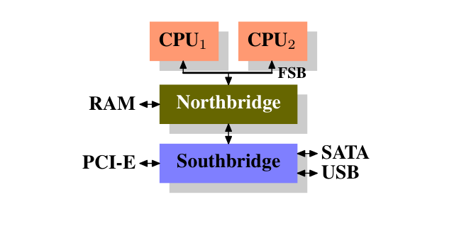

图2.1：带北桥和南桥的结构  
Figure 2.1: Structure with Northbridge and Southbridge

所有CPU（在上例中是两个，但也可以更多）都通过一条公共总线（前端总线，FSB）连接到北桥。北桥中除其他部件外还包含内存控制器，其实现决定了计算机所使用的RAM芯片类型。不同类型的RAM，例如DRAM、Rambus和SDRAM，需要不同的内存控制器。

All CPUs (two in the previous example, but there can be more) are connected via a common bus (the Front Side Bus, FSB) to the Northbridge. The Northbridge contains, among other things, the memory controller, and its implementation determines the type of RAM chips used for the computer. Different types of RAM, such as DRAM, Rambus, and SDRAM, require different memory controllers.

为了到达所有其他系统设备，北桥必须与南桥通信。南桥常被称为I/O桥，它通过各种不同的总线处理与设备的通信。如今最重要的是PCI、PCI Express、SATA和USB总线，但南桥也支持PATA、IEEE 1394、串口和并口。较老的系统有连接到北桥的AGP插槽。这样做是出于性能方面的原因，因为北桥与南桥之间的连接速度不够快。不过，如今PCI-E插槽都连接到南桥。

To reach all other system devices, the Northbridge must communicate with the Southbridge. The Southbridge, often referred to as the I/O bridge, handles communication with devices through a variety of different buses. Today the PCI, PCI Express, SATA, and USB buses are of most importance, but PATA, IEEE 1394, serial, and parallel ports are also supported by the Southbridge. Older systems had AGP slots which were attached to the Northbridge. This was done for performance reasons related to insufficiently fast connections between the Northbridge and Southbridge. However, today the PCI-E slots are all connected to the Southbridge.

这样的系统结构有若干值得注意的后果：

Such a system structure has a number of noteworthy consequences:

- 从一个CPU到另一个CPU的所有数据通信，都必须经过与北桥通信所用的同一条总线。

  All data communication from one CPU to another must travel over the same bus used to communicate with the Northbridge.
- 与RAM的所有通信都必须经过北桥。

  All communication with RAM must pass through the Northbridge.
- RAM只有一个端口。<sup>3</sup>

  The RAM has only a single port.<sup>3</sup>
- CPU与连接到南桥的设备之间的通信要经由北桥路由。

  Communication between a CPU and a device attached to the Southbridge is routed through the Northbridge.

这种设计中的几个瓶颈一目了然。其中一个瓶颈涉及设备对RAM的访问。在PC的最早期，与任一桥上设备的所有通信都必须经过CPU，这对整体系统性能产生了负面影响。为了解决这个问题，一些设备具备了直接内存访问（DMA）的能力。DMA使设备能够在北桥的帮助下，直接在RAM中存储和接收数据，而无需CPU的介入（以及随之而来的性能代价）。如今，连接到任何总线上的所有高性能设备都可以使用DMA。虽然这大大减轻了CPU的工作负担，但它也造成了对北桥带宽的争用，因为DMA请求要与来自CPU的RAM访问相互竞争。因此，这个问题必须加以考虑。

A couple of bottlenecks are immediately apparent in this design. One such bottleneck involves access to RAM for devices. In the earliest days of the PC, all communication with devices on either bridge had to pass through the CPU, negatively impacting overall system performance. To work around this problem some devices became capable of direct memory access (DMA). DMA allows devices, with the help of the Northbridge, to store and receive data in RAM directly without the intervention of the CPU (and its inherent performance cost). Today all high-performance devices attached to any of the buses can utilize DMA. While this greatly reduces the workload on the CPU, it also creates contention for the bandwidth of the Northbridge as DMA requests compete with RAM access from the CPUs. This problem, therefore, must be taken into account.

第二个瓶颈涉及从北桥到RAM的总线。该总线的确切细节取决于所部署的内存类型。在较老的系统上，只有一条总线通往所有RAM芯片，因此不可能并行访问。较新的RAM类型需要两条独立的总线（对于DDR2，它们被称为通道，见第8页），从而使可用带宽加倍。北桥在各通道之间交错进行内存访问。更新的内存技术（例如FB-DRAM）则增加了更多通道。

A second bottleneck involves the bus from the Northbridge to the RAM. The exact details of the bus depend on the memory types deployed. On older systems there is only one bus to all the RAM chips, so parallel access is not possible. Recent RAM types require two separate buses (or channels as they are called for DDR2, see page 8) which doubles the available bandwidth. The Northbridge interleaves memory access across the channels. More recent memory technologies (FB-DRAM, for instance) add more channels.

在可用带宽有限的情况下，以尽量减少延迟的方式调度内存访问，对性能而言非常重要。正如我们将看到的，处理器要快得多，即便使用了CPU缓存，它们也必须等待内存访问。如果多个超线程、内核或处理器同时访问内存，内存访问的等待时间就更长了。DMA操作也是如此。

With limited bandwidth available, it is important for performance to schedule memory access in ways that minimize delays. As we will see, processors are much faster and must wait to access memory, despite the use of CPU caches. If multiple hyper-threads, cores, or processors access memory at the same time, the wait times for memory access are even longer. This is also true for DMA operations.

不过，内存访问不仅仅关乎并发。访问模式本身也会极大地影响内存子系统的性能，尤其是在有多个内存通道的情况下。在2.2节中，我们将更详细地讨论RAM的访问模式。

There is more to accessing memory than concurrency, however. Access patterns themselves also greatly influence the performance of the memory subsystem, especially with multiple memory channels. In section 2.2 we will cover more details of RAM access patterns.

在一些更昂贵的系统上，北桥实际上并不包含内存控制器。相反，北桥可以连接到若干外部内存控制器（在下面的例子中是四个）。

On some more expensive systems, the Northbridge does not actually contain the memory controller. Instead the Northbridge can be connected to a number of external memory controllers (in the following example, four of them).

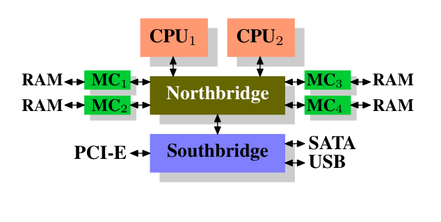

图2.2：带外部控制器的北桥  
Figure 2.2: Northbridge with External Controllers

这种架构的优点是存在不止一条内存总线，因此总可用带宽增加了。这种设计还支持更多的内存。并发的内存访问模式通过同时访问不同的内存条来减少延迟。当多个处理器直接连接到北桥时尤其如此，如图2.2所示。对于这样的设计，主要的限制是北桥的内部带宽，而对于这种（Intel的）架构，这一带宽是惊人的。<sup>4</sup>

The advantage of this architecture is that more than one memory bus exists and therefore total available bandwidth increases. This design also supports more memory. Concurrent memory access patterns reduce delays by simultaneously accessing different memory banks. This is especially true when multiple processors are directly connected to the Northbridge, as in Figure 2.2. For such a design, the primary limitation is the internal bandwidth of the Northbridge, which is phenomenal for this architecture (from Intel).<sup>4</sup>

使用多个外部内存控制器并不是增加内存带宽的唯一方法。另一种日益流行的方法是将内存控制器集成到CPU中，并为每个CPU连接内存。这种架构因基于AMD Opteron处理器的SMP系统而流行起来。图2.3展示了这样一个系统。Intel将从Nehalem处理器开始支持公共系统接口（CSI）；这基本上是同样的方法：一个集成的内存控制器，每个处理器都可以拥有本地内存。

Using multiple external memory controllers is not the only way to increase memory bandwidth. One other increasingly popular way is to integrate memory controllers into the CPUs and attach memory to each CPU. This architecture is made popular by SMP systems based on AMD’s Opteron processor. Figure 2.3 shows such a system. Intel will have support for the Common System Interface (CSI) starting with the Nehalem processors; this is basically the same approach: an integrated memory controller with the possibility of local memory for each processor.

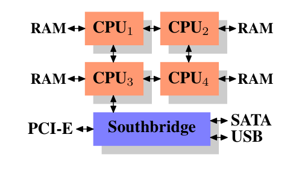

图2.3：集成内存控制器  
Figure 2.3: Integrated Memory Controller

在这样的架构下，可用的内存条数量与处理器数量一样多。在一台四CPU的机器上，内存带宽变为四倍，而无需一个带宽巨大的复杂北桥。将内存控制器集成到CPU中还有一些其他优点；我们在此不深入探讨这项技术。

With an architecture like this there are as many memory banks available as there are processors. On a quad-CPU machine the memory bandwidth is quadrupled without the need for a complicated Northbridge with enormous bandwidth. Having a memory controller integrated into the CPU has some additional advantages; we will not dig deeper into this technology here.

这种架构也有缺点。首先，由于机器仍然必须使系统的所有内存对所有处理器都可访问，内存就不再是一致的了（因此这种架构被称为NUMA——非一致内存架构）。本地内存（连接到某个处理器的内存）可以以通常的速度访问。访问连接到另一个处理器的内存时，情况就不同了。在这种情况下，必须使用处理器之间的互连。从CPU<sub>1</sub>访问连接到CPU<sub>2</sub>的内存，需要经过一个互连进行通信。同一个CPU访问连接到CPU<sub>4</sub>的内存时，则必须跨越两个互连。

There are disadvantages to this architecture, too. First of all, because the machine still has to make all the memory of the system accessible to all processors, the memory is not uniform anymore (hence the name NUMA - Non-Uniform Memory Architecture - for such an architecture). Local memory (memory attached to a processor) can be accessed with the usual speed. The situation is different when memory attached to another processor is accessed. In this case the interconnects between the processors have to be used. To access memory attached to CPU<sub>2</sub> from CPU<sub>1</sub> requires communication across one interconnect. When the same CPU accesses memory attached to CPU<sub>4</sub> two interconnects have to be crossed.

每次这样的通信都有相应的代价。当我们描述访问远程内存所需的额外时间时，我们称之为“NUMA因子”。图2.3中的示例架构对每个CPU有两个级别：紧邻的CPU，以及相隔两个互连的一个CPU。在更复杂的机器上，级别的数量可能显著增加。还有一些机器架构（例如IBM的x445和SGI的Altix系列）具有不止一种连接类型。CPU被组织成节点；在一个节点内部，访问内存的时间可能是一致的，或者只有很小的NUMA因子。不过，节点之间的连接可能非常昂贵，NUMA因子也可能相当高。

Each such communication has an associated cost. We talk about “NUMA factors” when we describe the extra time needed to access remote memory. The example architecture in Figure 2.3 has two levels for each CPU: immediately adjacent CPUs and one CPU which is two interconnects away. With more complicated machines the number of levels can grow significantly. There are also machine architectures (for instance IBM’s x445 and SGI’s Altix series) where there is more than one type of connection. CPUs are organized into nodes; within a node the time to access the memory might be uniform or have only small NUMA factors. The connection between nodes can be very expensive, though, and the NUMA factor can be quite high.

通用NUMA机器如今已经存在，并且在未来很可能发挥更大的作用。预计从2008年末起，每台SMP机器都将使用NUMA。与NUMA相关的代价使得识别程序何时运行在NUMA机器上变得很重要。在第5节中，我们将讨论更多的机器架构，以及Linux内核为这些程序提供的一些技术。

Commodity NUMA machines exist today and will likely play an even greater role in the future. It is expected that, from late 2008 on, every SMP machine will use NUMA. The costs associated with NUMA make it important to recognize when a program is running on a NUMA machine. In section 5 we will discuss more machine architectures and some technologies the Linux kernel provides for these programs.

除了本节其余部分所描述的技术细节之外，还有几个额外的因素会影响RAM的性能。它们不受软件控制，这就是本节没有涉及它们的原因。感兴趣的读者可以在2.1节中了解其中一些因素。只有在想更完整地了解RAM技术、或者在购买计算机时作出更好的决定时，才真正需要它们。

Beyond the technical details described in the remainder of this section, there are several additional factors which influence the performance of RAM. They are not controllable by software, which is why they are not covered in this section. The interested reader can learn about some of these factors in section 2.1. They are really only needed to get a more complete picture of RAM technology and possibly to make better decisions when purchasing computers.

接下来的两节讨论门级的硬件细节，以及内存控制器与DRAM芯片之间的访问协议。程序员很可能会觉得这些信息颇具启发性，因为这些细节解释了RAM访问为何以这种方式工作。不过，这是选读的知识，急于进入与日常工作更直接相关主题的读者可以直接跳到2.2.5节。

The following two sections discuss hardware details at the gate level and the access protocol between the memory controller and the DRAM chips. Programmers will likely find this information enlightening since these details explain why RAM access works the way it does. It is optional knowledge, though, and the reader anxious to get to topics with more immediate relevance for everyday life can jump ahead to section 2.2.5.

### 2.1 RAM的类型

### 2.1 RAM Types

多年来出现过许多类型的RAM，每种类型彼此之间都有差异，有时差异还很大。较老的类型如今实际上只有历史学家才会感兴趣。我们不会探讨它们的细节。相反，我们将专注于现代RAM类型；我们只会触及表面，探讨一些内核或应用程序开发者能通过其性能特征看到的细节。

There have been many types of RAM over the years and each type varies, sometimes significantly, from the other. The older types are today really only interesting to the historians. We will not explore the details of those. Instead we will concentrate on modern RAM types; we will only scrape the surface, exploring some details which are visible to the kernel or application developer through their performance characteristics.

第一批有趣的细节围绕这样一个问题：为什么同一台机器中会有不同类型的RAM？更具体地说，为什么既有静态RAM（SRAM<sup>5</sup>）又有动态RAM（DRAM）？前者要快得多，并且提供同样的功能。为什么机器中的RAM不全是SRAM？答案正如人们所料，是成本。SRAM的生产和使用成本都比DRAM高得多。这两个成本因素都很重要，而后者的重要性正日益增加。为了理解这些差异，我们来看看SRAM和DRAM中一个比特存储单元的实现。

The first interesting details are centered around the question why there are different types of RAM in the same machine. More specifically, why are there both static RAM (SRAM<sup>5</sup>) and dynamic RAM (DRAM). The former is much faster and provides the same functionality. Why is not all RAM in a machine SRAM? The answer is, as one might expect, cost. SRAM is much more expensive to produce and to use than DRAM. Both these cost factors are important, the second one increasing in importance more and more. To understand these differences we look at the implementation of a bit of storage for both SRAM and DRAM.

在本节的其余部分，我们将讨论RAM实现的一些底层细节。我们会尽量把细节层次保持在最低。为此，我们将在“逻辑层面”上讨论信号，而不是在硬件设计者必须使用的层面上。那种细节层次对于我们这里的目的来说是不必要的。

In the remainder of this section we will discuss some low-level details of the implementation of RAM. We will keep the level of detail as low as possible. To that end, we will discuss the signals at a “logic level” and not at a level a hardware designer would have to use. That level of detail is unnecessary for our purpose here.

#### 2.1.1 静态RAM

#### 2.1.1 Static RAM

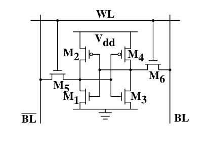

图2.4：6晶体管静态RAM  
Figure 2.4: 6-T Static RAM

图2.4展示了一个6晶体管SRAM单元的结构。该单元的核心由四个晶体管**M<sub>1</sub>**到**M<sub>4</sub>**构成，它们组成两个交叉耦合的反相器。它们有两个稳定状态，分别表示0和1。只要**V<sub>dd</sub>**上有电源，该状态就是稳定的。

Figure 2.4 shows the structure of a 6 transistor SRAM cell. The core of this cell is formed by the four transistors **M<sub>1</sub>** to **M<sub>4</sub>** which form two cross-coupled inverters. They have two stable states, representing 0 and 1 respectively. The state is stable as long as power on **V<sub>dd</sub>** is available.

如果需要访问该单元的状态，就把字访问线**WL**拉高。这使得单元的状态立即可在**BL**和**BL**上读取。如果必须改写单元的状态，就先把**BL**和**BL**线设置为所需的值，然后拉高**WL**。由于外部驱动器比四个晶体管（**M<sub>1</sub>**到**M<sub>4</sub>**）更强，这就能使旧状态被覆盖。

If access to the state of the cell is needed the word access line **WL** is raised. This makes the state of the cell immediately available for reading on **BL** and **BL**. If the cell state must be overwritten the **BL** and **BL** lines are first set to the desired values and then **WL** is raised. Since the outside drivers are stronger than the four transistors (**M<sub>1</sub>** through **M<sub>4</sub>**) this allows the old state to be overwritten.

关于该单元工作方式的更详细描述，见[20]。对于下面的讨论，需要注意的重要几点是：

See [20] for a more detailed description of the way the cell works. For the following discussion it is important to note that

- 一个单元需要六个晶体管。也有四晶体管的变体，但它们有缺点。

  one cell requires six transistors. There are variants with four transistors but they have disadvantages.
- 维持单元的状态需要持续供电。

  maintaining the state of the cell requires constant power.
- 一旦字访问线**WL**被拉高，单元状态几乎立即就可以读取。该信号与其他由晶体管控制的信号一样是矩形的（在两个二进制状态之间快速切换）。

  the cell state is available for reading almost immediately once the word access line **WL** is raised. The signal is as rectangular (changing quickly between the two binary states) as other transistor-controlled signals.
- 单元状态是稳定的，不需要刷新周期。

  the cell state is stable, no refresh cycles are needed.

还有其他更慢、更省电的SRAM形式，但由于我们关注的是快速RAM，它们在这里不是我们关心的对象。这些慢速变体之所以令人感兴趣，主要是因为它们的接口更简单，比动态RAM更容易在系统中使用。

There are other, slower and less power-hungry, SRAM forms available, but those are not of interest here since we are looking at fast RAM. These slow variants are mainly interesting because they can be more easily used in a system than dynamic RAM because of their simpler interface.

#### 2.1.2 动态RAM

#### 2.1.2 Dynamic RAM

动态RAM在结构上比静态RAM简单得多。图2.5展示了一种常见DRAM单元设计的结构。它仅由一个晶体管和一个电容器组成。复杂度上的这一巨大差异当然意味着它的工作方式与静态RAM截然不同。

Dynamic RAM is, in its structure, much simpler than static RAM. Figure 2.5 shows the structure of a usual DRAM cell design. All it consists of is one transistor and one capacitor. This huge difference in complexity of course means that it functions very differently than static RAM.

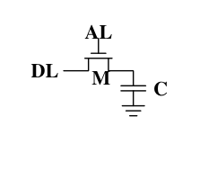

图2.5：1晶体管动态RAM  
Figure 2.5: 1-T Dynamic RAM

动态RAM单元将其状态保存在电容器**C**中。晶体管**M**用于把守对该状态的访问。要读取单元的状态，就把访问线**AL**拉高；根据电容器中的电荷，这要么会使电流在数据线**DL**上流动，要么不会。要写入该单元，就适当地设置数据线**DL**，然后把**AL**拉高足够长的时间，以便给电容器充电或放电。

A dynamic RAM cell keeps its state in the capacitor **C**. The transistor **M** is used to guard the access to the state. To read the state of the cell the access line **AL** is raised; this either causes a current to flow on the data line **DL** or not, depending on the charge in the capacitor. To write to the cell the data line **DL** is appropriately set and then **AL** is raised for a time long enough to charge or drain the capacitor.

动态RAM的设计有许多复杂之处。使用电容器意味着读取单元会使电容器放电。这个过程不能无限重复，电容器必须在某个时刻重新充电。更糟糕的是，为了容纳海量的单元（拥有10<sup>9</sup>个或更多单元的芯片如今很常见），电容器的容量必须很低（在飞法范围或更低）。一个充满电的电容器只能容纳几万个电子。尽管电容器的电阻很高（几太欧），电荷耗散所需的时间仍然很短。这个问题称为“漏电”。

There are a number of complications with the design of dynamic RAM. The use of a capacitor means that reading the cell discharges the capacitor. The procedure cannot be repeated indefinitely, the capacitor must be recharged at some point. Even worse, to accommodate the huge number of cells (chips with 10<sup>9</sup> or more cells are now common) the capacity to the capacitor must be low (in the femto-farad range or lower). A fully charged capacitor holds a few 10’s of thousands of electrons. Even though the resistance of the capacitor is high (a couple of tera-ohms) it only takes a short time for the capacity to dissipate. This problem is called “leakage”.

漏电正是DRAM单元必须不断刷新的原因。对于如今的大多数DRAM芯片，每64ms就必须刷新一次。在刷新周期内无法访问内存，因为刷新本质上就是一次结果被丢弃的内存读操作。对于某些工作负载，这项开销可能会使多达50%的内存访问停顿（见[3]）。

This leakage is why a DRAM cell must be constantly refreshed. For most DRAM chips these days this refresh must happen every 64ms. During the refresh cycle no access to the memory is possible since a refresh is simply a memory read operation where the result is discarded. For some workloads this overhead might stall up to 50% of the memory accesses (see [3]).

电荷极小所导致的第二个问题是，从单元中读出的信息不能直接使用。数据线必须连接到一个读出放大器，它能够在仍必须算作1的整个电荷范围内区分存储的是0还是1。

A second problem resulting from the tiny charge is that the information read from the cell is not directly usable. The data line must be connected to a sense amplifier which can distinguish between a stored 0 or 1 over the whole range of charges which still have to count as 1.

第三个问题是，读取一个单元会使电容器的电荷耗尽。这意味着每次读操作之后都必须跟随一次给电容器重新充电的操作。这是通过把读出放大器的输出反馈回电容器而自动完成的。不过，这确实意味着读取内存内容需要额外的能量，更重要的是需要额外的时间。

A third problem is that reading a cell causes the charge of the capacitor to be depleted. This means every read operation must be followed by an operation to recharge the capacitor. This is done automatically by feeding the output of the sense amplifier back into the capacitor. It does mean, though, the reading memory content requires additional energy and, more importantly, time.

这意味着电容器的充电和放电需要一些时间（由电容C和电阻R决定）。这也意味着读出放大器能够检测到的电流并不能立即获得。图2.6展示了充电和放电曲线。X轴以RC（电阻乘以电容）为单位度量，RC是一个时间单位。

This means it takes some time (determined by the capacity C and resistance R) for the capacitor to be charged and discharged. It also means that the current which can be detected by the sense amplifiers is not immediately available. Figure 2.6 shows the charge and discharge curves. The X–axis is measured in units of RC (resistance multiplied by capacitance) which is a unit of time.

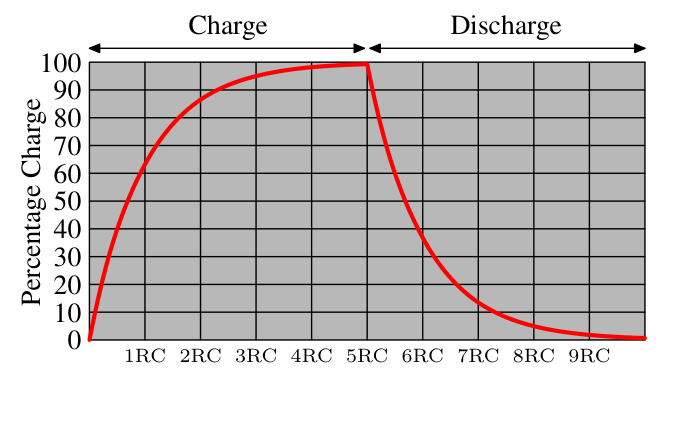

图2.6：电容器充电与放电时序  
Figure 2.6: Capacitor Charge and Discharge Timing

与静态RAM在字访问线被拉高时输出立即可用的情况不同，DRAM总是需要一点时间，直到电容器充分放电。这一延迟严重限制了DRAM所能达到的速度。

Unlike the static RAM case where the output is immediately available when the word access line is raised, it will always take a bit of time until the capacitor discharges sufficiently. This delay severely limits how fast DRAM can be.

这种简单的方法也有其优点。主要优点是尺寸。一个DRAM单元所需的芯片面积比一个SRAM单元小许多倍。SRAM单元还需要为维持状态的晶体管单独供电。DRAM单元的结构也更简单、更规整，这意味着在一块晶片上把许多单元紧密排列在一起更容易。

The simple approach has its advantages, too. The main advantage is size. The chip real estate needed for one DRAM cell is many times smaller than that of an SRAM cell. The SRAM cells also need individual power for the transistors maintaining the state. The structure of the DRAM cell is also simpler and more regular which means packing many of them close together on a die is simpler.

总的来说，（相当悬殊的）成本差异胜出。除了专用硬件——例如网络路由器——之外，我们不得不接受基于DRAM的主存。这对程序员有着巨大的影响，我们将在本文的其余部分讨论。但首先，我们需要再了解DRAM单元实际使用中的一些细节。

Overall, the (quite dramatic) difference in cost wins. Except in specialized hardware – network routers, for example – we have to live with main memory which is based on DRAM. This has huge implications on the programmer which we will discuss in the remainder of this paper. But first we need to look into a few more details of the actual use of DRAM cells.

#### 2.1.3 DRAM访问

#### 2.1.3 DRAM Access

程序使用虚拟地址来选择一个内存位置。处理器把它转换为物理地址，最后由内存控制器选择与该地址对应的RAM芯片。为了在RAM芯片上选中单个存储单元，物理地址的各部分以若干地址线的形式传递下去。

A program selects a memory location using a virtual address. The processor translates this into a physical address and finally the memory controller selects the RAM chip corresponding to that address. To select the individual memory cell on the RAM chip, parts of the physical address are passed on in the form of a number of address lines.

由内存控制器单独寻址各个内存位置是完全不切实际的：4GB的RAM将需要2<sup>32</sup>条地址线。取而代之的是，地址以二进制数的形式编码，通过一组较少的地址线传递。以这种方式传给DRAM芯片的地址必须先进行解复用。一个有*N*条地址线的解复用器会有2<sup>*N*</sup>条输出线。这些输出线可以用来选择存储单元。对于小容量芯片，使用这种直接方法问题不大。

It would be completely impractical to address memory locations individually from the memory controller: 4GB of RAM would require 2<sup>32</sup> address lines. Instead the address is passed encoded as a binary number using a smaller set of address lines. The address passed to the DRAM chip this way must be demultiplexed first. A demultiplexer with *N* address lines will have 2<sup>*N*</sup> output lines. These output lines can be used to select the memory cell. Using this direct approach is no big problem for chips with small capacities.

但是，如果单元数量增长，这种方法就不再适用了。一个1Gbit<sup>6</sup>容量的芯片将需要30条地址线和2<sup>30</sup>条选择线。在不牺牲速度的前提下，解复用器的大小随输入线数量呈指数增长。用于30条地址线的解复用器，除了解复用器本身的复杂度（尺寸和时间）之外，还需要大量的芯片面积。更重要的是，在地址线上同步传输30个脉冲，比“只”传输15个脉冲要困难得多。需要以完全相同的长度布设或进行适当定时的线路也更少。<sup>7</sup>

But if the number of cells grows this approach is not suitable anymore. A chip with 1Gbit<sup>6</sup> capacity would need 30 address lines and 2<sup>30</sup> select lines. The size of a demultiplexer increases exponentially with the number of input lines when speed is not to be sacrificed. A demultiplexer for 30 address lines needs a whole lot of chip real estate in addition to the complexity (size and time) of the demultiplexer. Even more importantly, transmitting 30 impulses on the address lines synchronously is much harder than transmitting “only” 15 impulses. Fewer lines have to be laid out at exactly the same length or timed appropriately.<sup>7</sup>

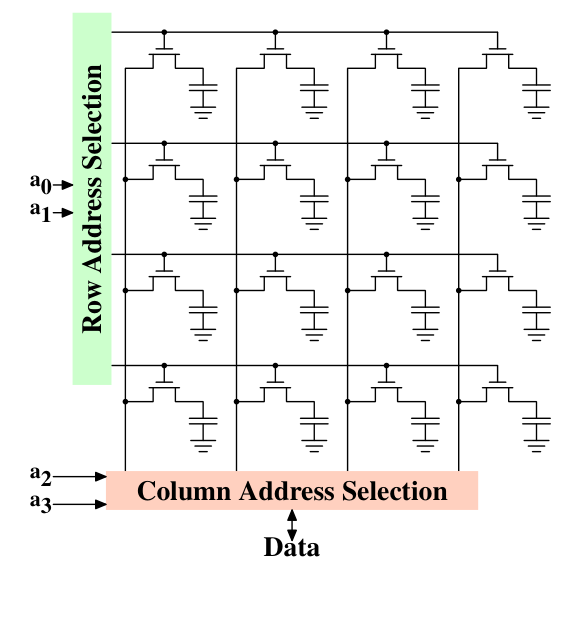

图2.7：动态RAM原理图  
Figure 2.7: Dynamic RAM Schematic

图2.7从非常高的层面展示了一块DRAM芯片。DRAM单元按行和列组织。它们本可以全部排成一行，但那样的话DRAM芯片就需要一个巨大的解复用器。采用阵列方式，设计只需一个解复用器和一个复用器，各为原来规模的一半即可。<sup>8</sup>这在各方面都是巨大的节省。在本例中，地址线**a<sub>0</sub>**和**a<sub>1</sub>**通过*行地址选择*（RAS）<sup>9</sup>解复用器选中一整行单元的地址线。读取时，所有单元的内容由此可供*列地址选择*（CAS）<sup>9</sup>复用器使用。根据地址线**a<sub>2</sub>**和**a<sub>3</sub>**，随后某一列的内容被提供给DRAM芯片的数据引脚。这一过程在多块DRAM芯片上并行进行多次，从而产生与数据总线宽度相对应的总位数。

Figure 2.7 shows a DRAM chip at a very high level. The DRAM cells are organized in rows and columns. They could all be aligned in one row but then the DRAM chip would need a huge demultiplexer. With the array approach the design can get by with one demultiplexer and one multiplexer of half the size.<sup>8</sup> This is a huge saving on all fronts. In the example the address lines **a<sub>0</sub>** and **a<sub>1</sub>** through the *row address selection* (RAS)<sup>9</sup> demultiplexer select the address lines of a whole row of cells. When reading, the content of all cells is thusly made available to the *column address selection* (CAS)<sup>9</sup> multiplexer. Based on the address lines **a<sub>2</sub>** and **a<sub>3</sub>** the content of one column is then made available to the data pin of the DRAM chip. This happens many times in parallel on a number of DRAM chips to produce a total number of bits corresponding to the width of the data bus.

写入时，新的单元值被放到数据总线上，当使用RAS和CAS选中该单元时，它就被存储到单元中。这是一个相当直截了当的设计。现实中——显然——还有许多复杂之处。需要规定信号发出后要延迟多久，数据才会出现在数据总线上供读取。正如上一节所述，电容器不会瞬间放电。来自单元的信号非常微弱，需要放大。对于写入，必须规定在RAS和CAS完成之后数据必须在总线上保持多久，才能成功地把新值存入单元（同样，电容器不会瞬间充满或放空）。这些时序常数对DRAM芯片的性能至关重要。我们将在下一节讨论这一点。

For writing, the new cell value is put on the data bus and, when the cell is selected using the RAS and CAS, it is stored in the cell. A pretty straightforward design. There are in reality – obviously – many more complications. There need to be specifications for how much delay there is after the signal before the data will be available on the data bus for reading. The capacitors do not unload instantaneously, as described in the previous section. The signal from the cells is so weak that it needs to be amplified. For writing it must be specified how long the data must be available on the bus after the RAS and CAS is done to successfully store the new value in the cell (again, capacitors do not fill or drain instantaneously). These timing constants are crucial for the performance of the DRAM chip. We will talk about this in the next section.

第二个可扩展性问题是，让每块RAM芯片都连接30条地址线也是不可行的。芯片的引脚是宝贵的资源。数据必须尽可能并行传输（例如以64位为一批）就已经够“糟”了。内存控制器必须能够寻址每个RAM模块（RAM芯片的集合）。如果出于性能原因需要并行访问多个RAM模块，而每个RAM模块都需要自己的一组30条或更多的地址线，那么对于8个RAM模块，内存控制器仅用于地址处理就需要多达240多个引脚。

A secondary scalability problem is that having 30 address lines connected to every RAM chip is not feasible either. Pins of a chip are precious resources. It is “bad” enough that the data must be transferred as much as possible in parallel (e.g., in 64 bit batches). The memory controller must be able to address each RAM module (collection of RAM chips). If parallel access to multiple RAM modules is required for performance reasons and each RAM module requires its own set of 30 or more address lines, then the memory controller needs to have, for 8 RAM modules, a whopping 240+ pins only for the address handling.

为了应对这些次要的可扩展性问题，DRAM芯片长期以来都对地址本身进行复用。这意味着地址分两部分传输。第一部分由地址位（图2.7例子中的**a<sub>0</sub>**和**a<sub>1</sub>**）组成，用于选择行。这一选择在被撤销之前一直有效。然后第二部分，即地址位**a<sub>2</sub>**和**a<sub>3</sub>**，选择列。关键的区别在于只需要两条外部地址线。还需要另外几条线来指示RAS和CAS信号何时可用，但与把地址线数量减半相比，这只是很小的代价。不过，这种地址复用也带来了它自己的一系列问题。我们将在2.2节中讨论它们。

To counter these secondary scalability problems DRAM chips have, for a long time, multiplexed the address itself. That means the address is transferred in two parts. The first part consisting of address bits (**a<sub>0</sub>** and **a<sub>1</sub>** in the example in Figure 2.7) select the row. This selection remains active until revoked. Then the second part, address bits **a<sub>2</sub>** and **a<sub>3</sub>**, select the column. The crucial difference is that only two external address lines are needed. A few more lines are needed to indicate when the RAS and CAS signals are available but this is a small price to pay for cutting the number of address lines in half. This address multiplexing brings its own set of problems, though. We will discuss them in section 2.2.

#### 2.1.4 结论

#### 2.1.4 Conclusions

如果本节中的细节有点让人应接不暇，请不必担心。本节需要记住的重要几点是：

Do not worry if the details in this section are a bit overwhelming. The important things to take away from this section are:

- 并非所有内存都是SRAM是有原因的

  there are reasons why not all memory is SRAM
- 存储单元需要被单独选中才能使用

  memory cells need to be individually selected to be used
- 地址线的数量直接决定了内存控制器、主板、DRAM模块和DRAM芯片的成本

  the number of address lines is directly responsible for the cost of the memory controller, motherboards, DRAM module, and DRAM chip
- 读或写操作的结果需要一段时间才能获得

  it takes a while before the results of the read or write operation are available

下一节将更详细地讨论访问DRAM内存的实际过程。我们不会深入讨论访问SRAM的更多细节，SRAM通常是直接寻址的。这样做是为了速度，也因为SRAM内存的容量有限。SRAM目前用于CPU缓存和片上存储，在那里连接很短，并且完全在CPU设计者的掌控之下。CPU缓存是我们稍后会讨论的话题，但我们现在需要知道的只是：SRAM单元有一定的最高速度，这取决于在SRAM上所投入的努力。其速度可以从仅比CPU内核略慢，到慢一两个数量级不等。

The following section will go into more details about the actual process of accessing DRAM memory. We are not going into more details of accessing SRAM, which is usually directly addressed. This happens for speed and because the SRAM memory is limited in size. SRAM is currently used in CPU caches and on-die where the connections are small and fully under control of the CPU designer. CPU caches are a topic which we discuss later but all we need to know is that SRAM cells have a certain maximum speed which depends on the effort spent on the SRAM. The speed can vary from only slightly slower than the CPU core to one or two orders of magnitude slower.

### 2.2 DRAM访问的技术细节

### 2.2 DRAM Access Technical Details

在介绍DRAM的那一节中我们看到，DRAM芯片对地址进行复用，以节省地址引脚形式的资源。我们还看到，访问DRAM单元需要时间，因为这些单元中的电容器不会瞬间放电从而产生稳定的信号；我们也看到DRAM单元必须刷新。现在是时候把这些都放在一起，看看所有这些因素如何决定DRAM访问必须以何种方式进行。

In the section introducing DRAM we saw that DRAM chips multiplex the addresses in order to save resources in the form of address pins. We also saw that accessing DRAM cells takes time since the capacitors in those cells do not discharge instantaneously to produce a stable signal; we also saw that DRAM cells must be refreshed. Now it is time to put this all together and see how all these factors determine how the DRAM access has to happen.

我们将专注于当前的技术；我们不讨论异步DRAM及其变体，因为它们已经根本不再相关了。对这一话题感兴趣的读者可参阅[3]和[19]。我们也不讨论Rambus DRAM（RDRAM），尽管这项技术并未过时。它只是没有被广泛用于系统内存。我们将只专注于同步DRAM（SDRAM）及其后继者双倍数据速率DRAM（DDR）。

We will concentrate on current technology; we will not discuss asynchronous DRAM and its variants as they are simply not relevant anymore. Readers interested in this topic are referred to [3] and [19]. We will also not talk about Rambus DRAM (RDRAM) even though the technology is not obsolete. It is just not widely used for system memory. We will concentrate exclusively on Synchronous DRAM (SDRAM) and its successors Double Data Rate DRAM (DDR).

同步DRAM，顾名思义，是相对于一个时间源工作的。内存控制器提供一个时钟，其频率决定了前端总线（FSB）——DRAM芯片所使用的内存控制器接口——的速度。在撰写本文时，800MHz、1,066MHz甚至1,333MHz的频率均已可用，更高的频率（1,600MHz）已宣布将用于下一代产品。这并不意味着总线上实际使用的频率有这么高。相反，如今的总线是双泵或四泵的，即每个周期传输两次或四次数据。数字越大越好卖，因此制造商喜欢把一条四泵200MHz总线宣传为“有效”800MHz总线。

Synchronous DRAM, as the name suggests, works relative to a time source. The memory controller provides a clock, the frequency of which determines the speed of the Front Side Bus (FSB) – the memory controller interface used by the DRAM chips. As of this writing, frequencies of 800MHz, 1,066MHz, or even 1,333MHz are available with higher frequencies (1,600MHz) being announced for the next generation. This does not mean the frequency used on the bus is actually this high. Instead, today’s buses are double- or quad-pumped, meaning that data is transported two or four times per cycle. Higher numbers sell so the manufacturers like to advertise a quad-pumped 200MHz bus as an “effective” 800MHz bus.

对于如今的SDRAM，每次数据传输包含64位——8字节。因此FSB的传输速率是8字节乘以有效总线频率（对于四泵200MHz总线为6.4GB/s）。这听起来很多，但它是突发速度，即永远不会被超越的最高速度。正如我们现在将看到的，与RAM模块通信的协议有大量无法传输数据的停顿时间。为了获得最佳性能，我们必须理解并尽量减少的正是这些停顿时间。

For SDRAM today each data transfer consists of 64 bits – 8 bytes. The transfer rate of the FSB is therefore 8 bytes multiplied by the effective bus frequency (6.4GB/s for the quad-pumped 200MHz bus). That sounds a lot but it is the burst speed, the maximum speed which will never be surpassed. As we will see now the protocol for talking to the RAM modules has a lot of downtime when no data can be transmitted. It is exactly this downtime which we must understand and minimize to achieve the best performance.

#### 2.2.1 读访问协议

#### 2.2.1 Read Access Protocol

图2.8展示了DRAM模块某些连接器上的活动，这些活动分为三个颜色不同的阶段。照例，时间从左向右流动。许多细节被省略了。这里我们只讨论总线时钟、RAS和CAS信号，以及地址总线和数据总线。一个读周期开始于内存控制器把行地址放到地址总线上并拉低RAS信号。所有信号都在时钟（CLK）的上升沿被读取，因此只要信号在被读取时是稳定的，它不完全是方波也没有关系。设置行地址会使RAM芯片开始锁存被寻址的行。

Figure 2.8 shows the activity on some of the connectors of a DRAM module which happens in three differently colored phases. As usual, time flows from left to right. A lot of details are left out. Here we only talk about the bus clock, RAS and CAS signals, and the address and data buses. A read cycle begins with the memory controller making the row address available on the address bus and lowering the RAS signal. All signals are read on the rising edge of the clock (CLK) so it does not matter if the signal is not completely square as long as it is stable at the time it is read. Setting the row address causes the RAM chip to start latching the addressed row.

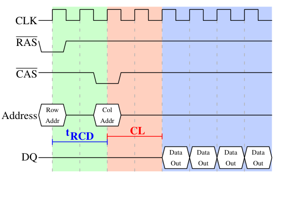

图2.8：SDRAM读访问时序  
Figure 2.8: SDRAM Read Access Timing

CAS信号可以在t<sub>RCD</sub>（RAS到CAS延迟）个时钟周期之后发出。然后，通过把列地址放到地址总线上并拉低CAS线来传输列地址。在这里我们可以看到，地址的两部分（大致各为一半，别的划分都没有意义）是如何通过同一条地址总线传输的。

The CAS signal can be sent after t<sub>RCD</sub> (RAS-to-CAS Delay) clock cycles. The column address is then transmitted by making it available on the address bus and lowering the CAS line. Here we can see how the two parts of the address (more or less halves, nothing else makes sense) can be transmitted over the same address bus.

现在寻址完成，数据可以传输了。RAM芯片需要一些时间为此做准备。这一延迟通常称为CAS延迟（CL）。在图2.8中，CAS延迟为2。根据内存控制器、主板和DRAM模块的质量，它可以更高或更低。延迟也可以取半值。若CL=2.5，第一个数据将在蓝色区域的第一个下降沿可用。

Now the addressing is complete and the data can be transmitted. The RAM chip needs some time to prepare for this. The delay is usually called CAS Latency (CL). In Figure 2.8 the CAS latency is 2. It can be higher or lower, depending on the quality of the memory controller, motherboard, and DRAM module. The latency can also have half values. With CL=2.5 the first data would be available at the first *falling* flank in the blue area.

为了获取数据做了这么多准备，如果只传输一个数据字就太浪费了。这就是为什么DRAM模块允许内存控制器指定要传输多少数据。通常可选的是2、4或8个字。这使得无需新的RAS/CAS序列就能填满缓存中的整行。内存控制器也可以在不重置行选择的情况下发送新的CAS信号。这样，连续的内存地址可以被显著更快地读取或写入，因为不必发送RAS信号，行也不必被停用（见下文）。是否让行保持“打开”，是内存控制器必须作出的决定。对于现实中的应用程序，投机性地一直让它保持打开是有缺点的（见[3]）。发送新的CAS信号只受RAM模块的命令速率约束（通常规定为T*x*，其中*x*是像1或2这样的值；对于每个周期都接受新命令的高性能DRAM模块，它将是1）。

With all this preparation to get to the data it would be wasteful to only transfer one data word. This is why DRAM modules allow the memory controller to specify how much data is to be transmitted. Often the choice is between 2, 4, or 8 words. This allows filling entire lines in the caches without a new RAS/CAS sequence. It is also possible for the memory controller to send a new CAS signal without resetting the row selection. In this way, consecutive memory addresses can be read from or written to significantly faster because the RAS signal does not have to be sent and the row does not have to be deactivated (see below). Keeping the row “open” is something the memory controller has to decide. Speculatively leaving it open all the time has disadvantages with real-world applications (see [3]). Sending new CAS signals is only subject to the Command Rate of the RAM module (usually specified as T*x*, where *x* is a value like 1 or 2; it will be 1 for high-performance DRAM modules which accept new commands every cycle).

在这个例子中，SDRAM每个周期输出一个字。第一代就是这样做的。DDR每个周期能够传输两个字。这缩短了传输时间，但并不改变延迟。原则上，DDR2的工作方式相同，尽管在实践中它看起来不一样。这里没有必要深入细节。只需指出DDR2可以做得更快、更便宜、更可靠，并且更节能就够了（更多信息见[6]）。

In this example the SDRAM spits out one word per cycle. This is what the first generation does. DDR is able to transmit two words per cycle. This cuts down on the transfer time but does not change the latency. In principle, DDR2 works the same although in practice it looks different. There is no need to go into the details here. It is sufficient to note that DDR2 can be made faster, cheaper, more reliable, and is more energy efficient (see [6] for more information).

#### 2.2.2 预充电与激活

#### 2.2.2 Precharge and Activation

图2.8并没有涵盖整个周期。它只展示了访问DRAM的完整周期的一部分。在可以发送新的RAS信号之前，当前被锁存的行必须被停用，新行必须被预充电。这里我们可以专注于通过显式命令完成这一操作的情况。协议有一些改进，在某些情况下可以避免这一额外步骤。不过，预充电所引入的延迟仍然会影响操作。

Figure 2.8 does not cover the whole cycle. It only shows parts of the full cycle of accessing DRAM. Before a new RAS signal can be sent the currently latched row must be deactivated and the new row must be precharged. We can concentrate here on the case where this is done with an explicit command. There are improvements to the protocol which, in some situations, allows this extra step to be avoided. The delays introduced by precharging still affect the operation, though.

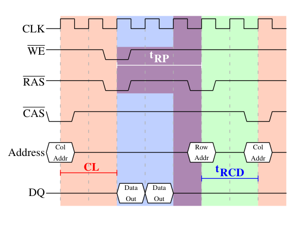

图2.9：SDRAM预充电与激活  
Figure 2.9: SDRAM Precharge and Activation

图2.9展示了从一个CAS信号到另一行的CAS信号之间的活动。用第一个CAS信号请求的数据与前面一样，在CL个周期之后可用。在这个例子中请求了两个字，在简单的SDRAM上传输它们需要两个周期。或者，可以想象在DDR芯片上传输四个字。

Figure 2.9 shows the activity starting from one CAS signal to the CAS signal for another row. The data requested with the first CAS signal is available as before, after CL cycles. In the example two words are requested which, on a simple SDRAM, takes two cycles to transmit. Alternatively, imagine four words on a DDR chip.

即便是在命令速率为1的DRAM模块上，预充电命令也不能立即发出。必须等待传输数据所需的时间。在这个例子中需要两个周期。这恰好与CL相同，但那只是巧合。预充电信号没有专用的线路；相反，一些实现通过同时拉低写使能（WE）线和RAS线来发出它。这种组合本身没有任何有用的含义（编码细节见[18]）。

Even on DRAM modules with a command rate of one the precharge command cannot be issued right away. It is necessary to wait as long as it takes to transmit the data. In this case it takes two cycles. This happens to be the same as CL but that is just a coincidence. The precharge signal has no dedicated line; instead, some implementations issue it by lowering the Write Enable (WE) and RAS line simultaneously. This combination has no useful meaning by itself (see [18] for encoding details).

一旦发出预充电命令，需要经过t<sub>RP</sub>（行预充电时间）个周期才能选择该行。在图2.9中，大部分时间（用紫色表示）与内存传输（浅蓝色）重叠。这很好！但t<sub>RP</sub>比传输时间长，因此下一个RAS信号被推迟了一个周期。

Once the precharge command is issued it takes t<sub>RP</sub> (Row Precharge time) cycles until the row can be selected. In Figure 2.9 much of the time (indicated by the purplish color) overlaps with the memory transfer (light blue). This is good! But t<sub>RP</sub> is larger than the transfer time and so the next RAS signal is stalled for one cycle.

如果我们把图中的时间线继续画下去，就会发现下一次数据传输发生在上一次传输停止5个周期之后。这意味着数据总线在七个周期中只有两个周期在使用。把这一点乘以FSB速度，800MHz总线理论上的6.4GB/s就变成了1.8GB/s。这很糟糕，必须避免。第6节中描述的技术有助于提高这个数字。但程序员通常也必须尽自己的一份力。

If we were to continue the timeline in the diagram we would find that the next data transfer happens 5 cycles after the previous one stops. This means the data bus is only in use two cycles out of seven. Multiply this with the FSB speed and the theoretical 6.4GB/s for a 800MHz bus become 1.8GB/s. That is bad and must be avoided. The techniques described in section 6 help to raise this number. But the programmer usually has to do her share.

SDRAM模块还有一个我们尚未讨论的时序值。在图2.9中，预充电命令只受数据传输时间的限制。另一个约束是，SDRAM模块在发出RAS信号之后，需要一段时间才能对另一行进行预充电（记为t<sub>RAS</sub>）。这个数值通常相当大，大约是t<sub>RP</sub>值的两到三倍。如果在一个RAS信号之后只跟着一个CAS信号，并且数据传输在几个周期内就完成了，这就成了问题。假设在图2.9中，最初的CAS信号之前直接是一个RAS信号，并且t<sub>RAS</sub>为8个周期。那么预充电命令就必须再推迟一个周期，因为t<sub>RCD</sub>、CL和t<sub>RP</sub>（因为它大于数据传输时间）之和只有7个周期。

There is one more timing value for a SDRAM module which we have not discussed. In Figure 2.9 the precharge command was only limited by the data transfer time. Another constraint is that an SDRAM module needs time after a RAS signal before it can precharge another row (denoted as t<sub>RAS</sub>). This number is usually pretty high, in the order of two or three times the t<sub>RP</sub> value. This is a problem if, after a RAS signal, only one CAS signal follows and the data transfer is finished in a few cycles. Assume that in Figure 2.9 the initial CAS signal was preceded directly by a RAS signal and that t<sub>RAS</sub> is 8 cycles. Then the precharge command would have to be delayed by one additional cycle since the sum of t<sub>RCD</sub>, CL, and t<sub>RP</sub> (since it is larger than the data transfer time) is only 7 cycles.

DDR模块常用一种特殊记法来描述：w-x-y-z-T。例如：2-3-2-8-T1。其含义是：

DDR modules are often described using a special notation: w-x-y-z-T. For instance: 2-3-2-8-T1. This means:

| w | 2 | CAS延迟（CL） CAS Latency (CL) |
| --- | --- | --- |
| x | 3 | RAS到CAS延迟（t<sub>RCD</sub>） RAS-to-CAS delay (t<sub>RCD</sub>) |
| y | 2 | RAS预充电（t<sub>RP</sub>） RAS Precharge (t<sub>RP</sub>) |
| z | 8 | 激活到预充电延迟（t<sub>RAS</sub>） Active to Precharge delay (t<sub>RAS</sub>) |
| T | T1 | 命令速率 Command Rate |

还有许多其他时序常数会影响命令的发出和处理方式。不过，在实践中这五个常数足以确定模块的性能。

There are numerous other timing constants which affect the way commands can be issued and are handled. Those five constants are in practice sufficient to determine the performance of the module, though.

为了能够解释某些测量结果，了解所用计算机的这些信息有时是有用的。在购买计算机时了解这些细节则绝对是有用的，因为它们与FSB和SDRAM模块速度一起，是决定计算机速度的最重要因素之一。

It is sometimes useful to know this information for the computers in use to be able to interpret certain measurements. It is definitely useful to know these details when buying computers since they, along with the FSB and SDRAM module speed, are among the most important factors determining a computer’s speed.

非常喜欢冒险的读者还可以尝试调校系统。有时BIOS允许修改其中部分或全部数值。SDRAM模块具有可编程寄存器，可以在其中设置这些值。通常BIOS会选择最佳默认值。如果RAM模块质量很高，也许可以在不影响计算机稳定性的情况下降低某一项或另一项延迟。互联网上众多的超频网站提供了大量相关文档。不过，这样做风险自负，别说没有警告过你。

The very adventurous reader could also try to tweak a system. Sometimes the BIOS allows changing some or all these values. SDRAM modules have programmable registers where these values can be set. Usually the BIOS picks the best default value. If the quality of the RAM module is high it might be possible to reduce the one or the other latency without affecting the stability of the computer. Numerous overclocking websites all around the Internet provide ample of documentation for doing this. Do it at your own risk, though and do not say you have not been warned.

#### 2.2.3 重新充电

#### 2.2.3 Recharging

谈到DRAM访问，一个经常被忽视的话题是重新充电。正如2.1.2节所解释的，DRAM单元必须不断刷新。这对系统的其余部分来说并不是完全透明的。当某一行<sup>10</sup>正在重新充电时，无法进行任何访问。[3]中的研究发现，“出人意料的是，DRAM的刷新组织方式会极大地影响性能”。

A mostly-overlooked topic when it comes to DRAM access is recharging. As explained in section 2.1.2, DRAM cells must constantly be refreshed. This does not happen completely transparently for the rest of the system. At times when a row<sup>10</sup> is recharged no access is possible. The study in [3] found that “*[s]urprisingly, DRAM refresh organization can affect performance dramatically*”.

根据JEDEC（联合电子器件工程委员会）规范，每个DRAM单元必须每64ms刷新一次。如果一个DRAM阵列有8,192行，这意味着内存控制器平均每7.8125µs就必须发出一次刷新命令（刷新命令可以排队，因此在实践中两次请求之间的最大间隔可以更长）。调度刷新命令是内存控制器的责任。DRAM模块会记录最后一个被刷新行的地址，并为每个新请求自动递增地址计数器。

Each DRAM cell must be refreshed every 64ms according to the [JEDEC](http://www.jedec.org/) (Joint Electron Device Engineering Council) specification. If a DRAM array has 8,192 rows this means the memory controller has to issue a refresh command on average every 7.8125µs (refresh commands can be queued so in practice the maximum interval between two requests can be higher). It is the memory controller’s responsibility to schedule the refresh commands. The DRAM module keeps track of the address of the last refreshed row and automatically increases the address counter for each new request.

对于刷新以及发出命令的时间点，程序员实在做不了什么。但在解释测量结果时，记住DRAM生命周期中的这一部分很重要。如果必须从一个正在刷新的行中取出一个关键字，处理器可能会停顿相当长的时间。每次刷新需要多长时间取决于DRAM模块。

There is really not much the programmer can do about the refresh and the points in time when the commands are issued. But it is important to keep this part of the DRAM life cycle in mind when interpreting measurements. If a critical word has to be retrieved from a row which currently is being refreshed the processor could be stalled for quite a long time. How long each refresh takes depends on the DRAM module.

#### 2.2.4 内存类型

#### 2.2.4 Memory Types

值得花些时间了解一下当前正在使用以及即将使用的内存类型。我们将从SDR（单倍数据速率）SDRAM开始，因为它们是DDR（双倍数据速率）SDRAM的基础。SDR相当简单。存储单元的速率与数据传输速率是相同的。

It is worth spending some time on the current and soon-to-be current memory types in use. We will start with SDR (Single Data Rate) SDRAMs since they are the basis of the DDR (Double Data Rate) SDRAMs. SDRs were pretty simple. The memory cells and the data transfer rate were identical.

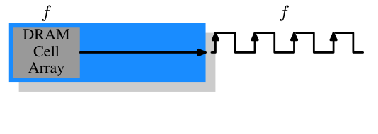

图2.10：SDR SDRAM的工作方式  
Figure 2.10: SDR SDRAM Operation

在图2.10中，DRAM单元阵列能以内存总线所能传输的相同速率输出内存内容。如果DRAM单元阵列能以100MHz工作，那么单个单元的总线数据传输速率就是100Mb/s。所有组件的频率*f*都相同。提高DRAM芯片的吞吐量代价高昂，因为能耗随频率上升。对于海量的阵列单元而言，这代价高得令人望而却步。<sup>11</sup>实际上，问题还要更严重，因为提高频率通常还需要提高电压以维持系统的稳定性。DDR SDRAM（后来被称为DDR1）设法在不提高任何相关频率的情况下提高了吞吐量。

In Figure 2.10 the DRAM cell array can output the memory content at the same rate it can be transported over the memory bus. If the DRAM cell array can operate at 100MHz, the data transfer rate of the bus of a single cell is thus 100Mb/s. The frequency *f* for all components is the same. Increasing the throughput of the DRAM chip is expensive since the energy consumption rises with the frequency. With a huge number of array cells this is prohibitively expensive.<sup>11</sup> In reality it is even more of a problem since increasing the frequency usually also requires increasing the voltage to maintain stability of the system. DDR SDRAM (called DDR1 retroactively) manages to improve the throughput without increasing any of the involved frequencies.

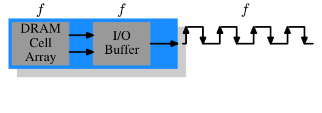

图2.11：DDR1 SDRAM的工作方式  
Figure 2.11: DDR1 SDRAM Operation

SDR与DDR1的区别，正如在图2.11中可以看到、也可以从名称中猜到的那样，在于每个周期传输的数据量是原来的两倍。也就是说，DDR1芯片在上升沿和下降沿都传输数据。这有时被称为“双泵”总线。为了在不提高单元阵列频率的情况下实现这一点，必须引入一个缓冲区。这个缓冲区为每条数据线保存两位。这反过来又要求图2.7的单元阵列中数据总线由两条线组成。实现这一点很简单：只需对两个DRAM单元使用相同的列地址，并并行访问它们即可。为实现这一点对单元阵列所作的改动也很小。

The difference between SDR and DDR1 is, as can be seen in Figure 2.11 and guessed from the name, that twice the amount of data is transported per cycle. I.e., the DDR1 chip transports data on the rising *and* falling edge. This is sometimes called a “double-pumped” bus. To make this possible without increasing the frequency of the cell array a buffer has to be introduced. This buffer holds two bits per data line. This in turn requires that, in the cell array in Figure 2.7, the data bus consists of two lines. Implementing this is trivial: one only has to use the same column address for two DRAM cells and access them in parallel. The changes to the cell array to implement this are also minimal.

SDR DRAM仅以其频率来称呼（例如，100MHz SDR称为PC100）。为了让DDR1 DRAM听起来更好，由于频率没有变化，市场营销人员不得不想出一套新的命名方案。他们想出的名称包含DDR模块（它们有64位总线）所能维持的以字节计的传输速率：

The SDR DRAMs were known simply by their frequency (e.g., PC100 for 100MHz SDR). To make DDR1 DRAM sound better the marketers had to come up with a new scheme since the frequency did not change. They came with a name which contains the transfer rate in bytes a DDR module (they have 64-bit busses) can sustain:

$$100MHz×64bit×2=1,600MB/s$$

因此，频率为100MHz的DDR模块被称为PC1600。由于1600 > 100，所有营销需求都得到了满足；它听起来好得多，尽管改进实际上只是两倍而已。<sup>12</sup>

Hence a DDR module with 100MHz frequency is called PC1600. With 1600 > 100 all marketing requirements are fulfilled; it sounds much better although the improvement is really *only* a factor of two.<sup>12</sup>

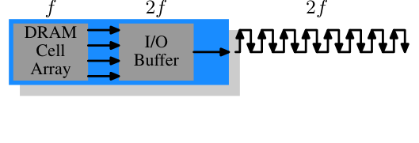

图2.12：DDR2 SDRAM的工作方式  
Figure 2.12: DDR2 SDRAM Operation

为了从内存技术中榨取更多性能，DDR2引入了更多的创新。从图2.12中可以看出，最明显的变化是总线频率加倍。频率加倍意味着带宽加倍。由于对单元阵列而言，频率加倍并不经济，现在要求I/O缓冲区在每个时钟周期获取四位，然后再把它们发送到总线上。这意味着对DDR2模块的改动只在于让DIMM的I/O缓冲区组件能够以更高的速度运行。这当然是可能的，并且不会需要明显更多的能量，因为它只是一个很小的组件，而不是整个模块。营销人员为DDR2想出的名称与DDR1的名称类似，只是在计算数值时把因子2换成了4（我们现在有了四泵总线）。表2.1列出了如今正在使用的模块名称。

To get even more out of the memory technology DDR2 includes a bit more innovation. The most obvious change that can be seen in Figure 2.12 is the doubling of the frequency of the bus. Doubling the frequency means doubling the bandwidth. Since this doubling of the frequency is not economical for the cell array it is now required that the I/O buffer gets four bits in each clock cycle which it then can send on the bus. This means the changes to the DDR2 modules consist of making only the I/O buffer component of the DIMM capable of running at higher speeds. This is certainly possible and will not require measurably more energy, it is just one tiny component and not the whole module. The names the marketers came up with for DDR2 are similar to the DDR1 names only in the computation of the value the factor of two is replaced by four (we now have a quad-pumped bus). Table 2.1 shows the names of the modules in use today.

| 阵列频率 Array Freq. | 总线频率 Bus Freq. | 数据速率 Data Rate | 名称（速率） Name (Rate) | 名称（FSB） Name (FSB) |
| --- | --- | --- | --- | --- |
| 133MHz | 266MHz | 4,256MB/s | PC2-4200 | DDR2-533 |
| 166MHz | 333MHz | 5,312MB/s | PC2-5300 | DDR2-667 |
| 200MHz | 400MHz | 6,400MB/s | PC2-6400 | DDR2-800 |
| 250MHz | 500MHz | 8,000MB/s | PC2-8000 | DDR2-1000 |
| 266MHz | 533MHz | 8,512MB/s | PC2-8500 | DDR2-1066 |

表2.1：DDR2模块名称  
Table 2.1: DDR2 Module Names

命名还有一处转折。CPU、主板和DRAM模块所使用的FSB速度是用*有效*频率来规定的。也就是说，它计入了在时钟周期两个沿上的传输，从而夸大了数字。因此，一个带266MHz总线的133MHz模块，其FSB“频率”为533MHz。

There is one more twist to the naming. The FSB speed used by CPU, motherboard, and DRAM module is specified by using the *effective* frequency. I.e., it factors in the transmission on both flanks of the clock cycle and thereby inflates the number. So, a 133MHz module with a 266MHz bus has an FSB “frequency” of 533MHz.

DDR3（真正的DDR3，而不是显卡中使用的冒牌GDDR3）的规范要求沿着向DDR2过渡的方向作出更多改变。电压将从DDR2的1.8V降低到DDR3的1.5V。由于功耗公式是用电压的平方计算的，仅此一项就带来30%的改进。再加上晶片尺寸的缩小以及其他电气方面的进步，DDR3在相同频率下能够以一半的功耗运行。或者，在更高的频率下，可以达到相同的功耗包络。或者，以两倍的容量达到相同的散热量。

The specification for DDR3 (the real one, not the fake GDDR3 used in graphics cards) calls for more changes along the lines of the transition to DDR2. The voltage will be reduced from 1.8V for DDR2 to 1.5V for DDR3. Since the power consumption equation is calculated using the square of the voltage this alone brings a 30% improvement. Add to this a reduction in die size plus other electrical advances and DDR3 can manage, at the same frequency, to get by with half the power consumption. Alternatively, with higher frequencies, the same power envelope can be hit. Or with double the capacity the same heat emission can be achieved.

DDR3模块的单元阵列将以外部总线速度的四分之一运行，这需要一个8位的I/O缓冲区，比DDR2的4位有所增加。原理图见图2.13。

The cell array of DDR3 modules will run at a quarter of the speed of the external bus which requires an 8 bit I/O buffer, up from 4 bits for DDR2. See Figure 2.13 for the schematics.

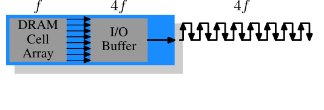

图2.13：DDR3 SDRAM的工作方式  
Figure 2.13: DDR3 SDRAM Operation

最初，DDR3模块的CAS延迟可能会略高一些，仅仅是因为DDR2技术更成熟。这将使得DDR3只有在高于DDR2所能达到的频率时才有用，即便如此，也主要是在带宽比延迟更重要的时候。已经有人在谈论能够达到与DDR2相同CAS延迟的1.3V模块。无论如何，由于总线更快而获得更高速度的可能性，将会超过延迟增加带来的影响。

Initially DDR3 modules will likely have slightly higher CAS latencies just because the DDR2 technology is more mature. This would cause DDR3 to be useful only at frequencies which are higher than those which can be achieved with DDR2, and, even then, mostly when bandwidth is more important than latency. There is already talk about 1.3V modules which can achieve the same CAS latency as DDR2. In any case, the possibility of achieving higher speeds because of faster buses will outweigh the increased latency.

DDR3一个可能的问题是，对于1,600Mb/s或更高的传输速率，每个通道的模块数可能会减少到只有一个。在早期版本中，这一要求适用于所有频率，因此人们可以希望这一要求在某个时候对所有频率都被取消。否则，系统的容量将受到严重限制。

One possible problem with DDR3 is that, for 1,600Mb/s transfer rate or higher, the number of modules per channel may be reduced to just one. In earlier versions this requirement held for all frequencies, so one can hope that the requirement will at some point be lifted for all frequencies. Otherwise the capacity of systems will be severely limited.

表2.2列出了我们可能会看到的DDR3模块的名称。到目前为止，JEDEC已就前四种类型达成一致。鉴于Intel的45nm处理器的FSB速度为1,600Mb/s，1,866Mb/s是超频市场所需要的。在DDR3生命周期接近尾声时，我们很可能会看到更多此类产品。

Table 2.2 shows the names of the DDR3 modules we are likely to see. JEDEC agreed so far on the first four types. Given that Intel’s 45nm processors have an FSB speed of 1,600Mb/s, the 1,866Mb/s is needed for the overclocking market. We will likely see more of this towards the end of the DDR3 lifecycle.

| 阵列频率 Array Freq. | 总线频率 Bus Freq. | 数据速率 Data Rate | 名称（速率） Name (Rate) | 名称（FSB） Name (FSB) |
| --- | --- | --- | --- | --- |
| 100MHz | 400MHz | 6,400MB/s | PC3-6400 | DDR3-800 |
| 133MHz | 533MHz | 8,512MB/s | PC3-8500 | DDR3-1066 |
| 166MHz | 667MHz | 10,667MB/s | PC3-10667 | DDR3-1333 |
| 200MHz | 800MHz | 12,800MB/s | PC3-12800 | DDR3-1600 |
| 233MHz | 933MHz | 14,933MB/s | PC3-14900 | DDR3-1866 |

表2.2：DDR3模块名称  
Table 2.2: DDR3 Module Names

所有DDR内存都有一个问题：总线频率的提高使得构建并行数据总线变得困难。一个DDR2模块有240个引脚。所有到数据引脚和地址引脚的连接都必须这样布线：使它们的长度大致相同。更麻烦的是，如果要在同一条总线上菊花链式连接不止一个DDR模块，每增加一个模块，信号的失真就越来越严重。DDR2规范只允许每条总线（又称通道）上有两个模块，DDR3规范在高频率下只允许一个模块。由于每个通道有240个引脚，单个北桥无法合理地驱动两个以上的通道。另一种选择是使用外部内存控制器（如图2.2所示），但这很昂贵。

All DDR memory has one problem: the increased bus frequency makes it hard to create parallel data busses. A DDR2 module has 240 pins. All connections to data and address pins must be routed so that they have approximately the same length. Even more of a problem is that, if more than one DDR module is to be daisy-chained on the same bus, the signals get more and more distorted for each additional module. The DDR2 specification allow only two modules per bus (aka channel), the DDR3 specification only one module for high frequencies. With 240 pins per channel a single Northbridge cannot reasonably drive more than two channels. The alternative is to have external memory controllers (as in Figure 2.2) but this is expensive.

这意味着通用主板最多只能容纳四个DDR2或DDR3模块。这一限制严重限制了系统所能拥有的内存数量。即使是老旧的32位IA-32处理器也能处理64GB的RAM，而且即使是家庭用途的内存需求也在增长，所以必须做点什么。

What this means is that commodity motherboards are restricted to hold at most four DDR2 or DDR3 modules. This restriction severely limits the amount of memory a system can have. Even old 32-bit IA-32 processors can handle 64GB of RAM and memory demand even for home use is growing, so something has to be done.

一个解决办法是像第2节所解释的那样，把内存控制器加入到每个处理器中。AMD在Opteron产品线上这样做了，Intel也将通过其CSI技术这样做。只要处理器能够使用的合理数量的内存可以连接到单个处理器上，这就会有所帮助。在某些情况下情况并非如此，而这种配置将引入NUMA架构及其负面影响。在某些情况下需要另一种解决方案。

One answer is to add memory controllers into each processor as explained in section 2. AMD does it with the Opteron line and Intel will do it with their CSI technology. This will help as long as the reasonable amount of memory a processor is able to use can be connected to a single processor. In some situations this is not the case and this setup will introduce a NUMA architecture and its negative effects. For some situations another solution is needed.

Intel针对大型服务器机器的这一问题的解决方案，至少目前，称为全缓冲DRAM（FB-DRAM）。FB-DRAM模块使用与当今DDR2模块相同的内存芯片，这使得它们的生产成本相对较低。区别在于与内存控制器的连接方式。FB-DRAM不使用并行数据总线，而是使用串行总线（Rambus DRAM早在当年就有这个，SATA是PATA的后继者，PCI Express是PCI/AGP的后继者，也是如此）。串行总线可以在高得多的频率下驱动，从而扭转串行化的负面影响，甚至提高带宽。使用串行总线的主要效果是

Intel’s answer to this problem for big server machines, at least at the moment, is called Fully Buffered DRAM (FB-DRAM). The FB-DRAM modules use the same memory chips as today’s DDR2 modules which makes them relatively cheap to produce. The difference is in the connection with the memory controller. Instead of a parallel data bus FB-DRAM utilizes a serial bus (Rambus DRAM had this back when, too, and SATA is the successor of PATA, as is PCI Express for PCI/AGP). The serial bus can be driven at a much higher frequency, reverting the negative impact of the serialization and even increasing the bandwidth. The main effects of using a serial bus are

1. 每个通道可以使用更多模块。

   more modules per channel can be used.
2. 每个北桥/内存控制器可以使用更多通道。

   more channels per Northbridge/memory controller can be used.
3. 串行总线被设计为全双工的（两条线）。

   the serial bus is designed to be fully-duplex (two lines).
4. 实现差分总线（每个方向两条线）的成本足够低，从而可以提高速度。

   it is cheap enough to implement a differential bus (two lines in each direction) and so increase the speed.

与DDR2的240个引脚相比，一个FB-DRAM模块只有69个引脚。菊花链式连接FB-DRAM模块要容易得多，因为总线的电气效应可以得到好得多的处理。FB-DRAM规范允许每个通道最多8个DRAM模块。

An FB-DRAM module has only 69 pins, compared with the 240 for DDR2. Daisy chaining FB-DRAM modules is much easier since the electrical effects of the bus can be handled much better. The FB-DRAM specification allows up to 8 DRAM modules per channel.

与双通道北桥的连接需求相比，现在可以用更少的引脚驱动6个FB-DRAM通道：2×240个引脚对比6×69个引脚。每个通道的布线也简单得多，这也有助于降低主板的成本。

Compared with the connectivity requirements of a dual-channel Northbridge it is now possible to drive 6 channels of FB-DRAM with fewer pins: 2×240 pins versus 6×69 pins. The routing for each channel is much simpler which could also help reducing the cost of the motherboards.

对于传统DRAM模块，全双工并行总线的成本高得令人望而却步，把所有这些线路都复制一遍代价太大。对于串行线路（即使像FB-DRAM所要求的那样是差分的），情况并非如此，因此串行总线被设计为全双工的，这意味着在某些情况下，仅此一项就使带宽在理论上翻了一番。但这并不是唯一利用并行性来提高带宽的地方。由于一个FB-DRAM控制器可以同时运行多达六个通道，即使对于RAM容量较小的系统，使用FB-DRAM也可以提高带宽。在一个有四个模块的DDR2系统有两个通道的地方，使用普通的FB-DRAM控制器可以通过四个通道来处理相同的容量。串行总线的实际带宽取决于FB-DRAM模块上所使用的DDR2（或DDR3）芯片的类型。

Fully duplex parallel busses are prohibitively expensive for the traditional DRAM modules, duplicating all those lines is too costly. With serial lines (even if they are differential, as FB-DRAM requires) this is not the case and so the serial bus is designed to be fully duplexed, which means, in some situations, that the bandwidth is theoretically doubled alone by this. But it is not the only place where parallelism is used for bandwidth increase. Since an FB-DRAM controller can run up to six channels at the same time the bandwidth can be increased even for systems with smaller amounts of RAM by using FB-DRAM. Where a DDR2 system with four modules has two channels, the same capacity can be handled via four channels using an ordinary FB-DRAM controller. The actual bandwidth of the serial bus depends on the type of DDR2 (or DDR3) chips used on the FB-DRAM module.

我们可以把优势总结如下：

We can summarize the advantages like this:

|  | DDR2 | FB-DRAM |
| --- | --- | --- |
| 引脚 Pins | 240 | 69 |
| 通道 Channels | 2 | 6 |
| 每通道DIMM数 DIMMs/Channel | 2 | 8 |
| 最大内存<sup>13</sup> Max Memory | 16GB<sup>14</sup> | 192GB |
| 吞吐量<sup>15</sup> Throughput | ~10GB/s | ~40GB/s |

如果在一个通道上使用多个DIMM，FB-DRAM会有一些缺点。信号在链上的每个DIMM处都会被延迟——尽管只是极小的延迟——从而增加了延迟。第二个问题是，由于频率非常高并且需要驱动总线，驱动串行总线的芯片需要相当多的能量。但对于相同频率下相同数量的内存，FB-DRAM总是可以比DDR2和DDR3更快，因为多达四个DIMM中的每一个都可以拥有自己的通道；对于大内存系统，DDR使用通用组件根本无法应对。

There are a few drawbacks to FB-DRAMs if multiple DIMMs on one channel are used. The signal is delayed–albeit minimally–at each DIMM in the chain, thereby increasing the latency. A second problem is that the chip driving the serial bus requires significant amounts of energy because of the very high frequency and the need to drive a bus. But for the same amount of memory with the same frequency FB-DRAM can always be faster than DDR2 and DDR3 since the up-to four DIMMS can each get their own channel; for large memory systems DDR simply has no answer using commodity components.

#### 2.2.5 结论

#### 2.2.5 Conclusions

本节应该已经表明，访问DRAM并不是一个可以任意快的过程。至少，与处理器运行的速度以及它访问寄存器和缓存的速度相比并不快。必须牢记CPU频率与内存频率之间的差异。一颗运行在2.933GHz的Intel Core 2处理器与1.066GHz的FSB，其时钟比为11:1（注意：1.066GHz总线是四泵的）。内存总线上每停顿一个周期，就意味着处理器停顿11个周期。对于大多数机器，实际使用的DRAM更慢，从而进一步增加了延迟。在接下来的各节中讨论停顿时，请记住这些数字。

This section should have shown that accessing DRAM is not an arbitrarily fast process. At least not fast compared with the speed the processor is running and with which it can access registers and cache. It is important to keep in mind the differences between CPU and memory frequencies. An Intel Core 2 processor running at 2.933GHz and a 1.066GHz FSB have a clock ratio of 11:1 (note: the 1.066GHz bus is quad-pumped). Each stall of one cycle on the memory bus means a stall of 11 cycles for the processor. For most machines the actual DRAMs used are slower, thusly increasing the delay. Keep these numbers in mind when we are talking about stalls in the upcoming sections.

读命令的时序图表明，DRAM模块能够维持很高的持续数据速率。整个DRAM行可以在没有任何停顿的情况下传输。数据总线可以保持100%的占用。对于DDR模块，这意味着每个周期传输两个64位字。对于DDR2-800模块和两个通道，这意味着12.8GB/s的速率。

The timing charts for the read command have shown that DRAM modules are capable of high sustained data rates. Entire DRAM rows could be transported without a single stall. The data bus could be kept occupied 100%. For DDR modules this means two 64-bit words transferred each cycle. With DDR2-800 modules and two channels this means a rate of 12.8GB/s.

但是，除非专门这样设计，DRAM访问并不总是顺序的。程序会使用不连续的内存区域，这意味着需要预充电和新的RAS信号。这时速度就会变慢，DRAM模块就需要帮助了。预充电越早发生、RAS信号越早发出，在实际使用该行时的代价就越小。

But, unless designed this way, DRAM access is not always sequential. Non-continuous memory regions are used which means precharging and new RAS signals are needed. This is when things slow down and when the DRAM modules need help. The sooner the precharging can happen and the RAS signal sent the smaller the penalty when the row is actually used.

硬件预取和软件预取（见6.3节）可以用来在时序上创造更多的重叠，减少停顿。预取还有助于在时间上转移内存操作，从而在稍后、即实际需要数据之前的那一刻减少争用。当一轮中产生的数据必须被存储、而下一轮所需的数据必须被读取时，这是一个常见的问题。通过在时间上提前读取，写操作和读操作就不必在基本相同的时间发出。

Hardware and software prefetching (see section 6.3) can be used to create more overlap in the timing and reduce the stall. Prefetching also helps shift memory operations in time so that there is less contention at later times, right before the data is actually needed. This is a frequent problem when the data produced in one round has to be stored and the data required for the next round has to be read. By shifting the read in time, the write and read operations do not have to be issued at basically the same time.

### 2.3 其他主存使用者

### 2.3 Other Main Memory Users

除了CPU之外，还有其他系统组件可以访问主存。网络和大容量存储控制器等高性能卡负担不起把它们需要或提供的所有数据都经由CPU传递。相反，它们直接从主存读取或向主存写入数据（直接内存访问，DMA）。从图2.1中可以看到，这些卡可以通过南桥和北桥直接与内存通信。其他总线，例如USB，也需要FSB带宽——即使它们不使用DMA——因为南桥也是经由北桥、通过FSB连接到处理器的。

Beside CPUs there are other system components which can access the main memory. High-performance cards such as network and mass-storage controllers cannot afford to pipe all the data they need or provide through the CPU. Instead, they read or write the data directly from/to the main memory (Direct Memory Access, DMA). In Figure 2.1 we can see that the cards can talk through the South- and Northbridge directly with the memory. Other buses, like USB, also require FSB bandwidth–even if they do not use DMA–since the Southbridge is connected via the Northbridge to the processor through the FSB, too.

虽然DMA无疑是有益的，但它意味着对FSB带宽的竞争更加激烈。在DMA流量很大的时候，CPU在等待来自主存的数据时可能会比平时停顿得更多。只要有合适的硬件，就有办法绕过这个问题。在图2.3那样的架构中，可以确保计算使用不受DMA影响的节点上的内存。也可以为每个节点连接一个南桥，把负载均匀地分布到所有节点的FSB上。可能性多种多样。在第6节中，我们将介绍有助于实现软件中可能的改进的技术和编程接口。

While DMA is certainly beneficial, it means that there is more competition for the FSB bandwidth. In times with high DMA traffic the CPU might stall more than usual while waiting for data from the main memory. There are ways around this given the right hardware. With an architecture as in Figure 2.3 one can make sure the computation uses memory on nodes which are not affected by DMA. It is also possible to attach a Southbridge to each node, equally distributing the load on the FSB of all the nodes. There are a myriad of possibilities. In section 6 we will introduce techniques and programming interfaces which help achieving the improvements which are possible in software.

最后应当提到，一些廉价系统的图形系统没有单独的专用显存。这些系统把主存的一部分用作显存。由于对显存的访问很频繁（对于一个以60Hz刷新的1024x768、16bpp的显示器，我们说的是94MB/s），而且系统内存与显卡上的RAM不同，没有两个端口，这会严重影响系统的性能，尤其是延迟。在性能优先的情况下，最好忽略这类系统。它们带来的麻烦比价值更多。购买这些机器的人知道他们不会得到最好的性能。

Finally it should be mentioned that some cheap systems have graphics systems without separate, dedicated video RAM. Those systems use parts of the main memory as video RAM. Since access to the video RAM is frequent (for a 1024x768 display with 16 bpp at 60Hz we are talking 94MB/s) and system memory, unlike RAM on graphics cards, does not have two ports this can substantially influence the systems performance and especially the latency. It is best to ignore such systems when performance is a priority. They are more trouble than they are worth. People buying those machines know they will not get the best performance.

[^2]: ↑ 超线程使单个处理器内核只需少量额外硬件，就能用于两个或更多的并发执行。

    ↑ Hyper-threading enables a single processor core to be used for two or more concurrent executions with just a little extra hardware.
[^3]: ↑ 本文不讨论多端口RAM，因为这类RAM在通用硬件中找不到，至少在程序员可以接触到的地方找不到。它可以在网络路由器等依赖极致速度的专用硬件中找到。

    ↑ We will not discuss multi-port RAM in this document as this type of RAM is not found in commodity hardware, at least not in places where the programmer has access to it. It can be found in specialized hardware such as network routers which depend on utmost speed.
[^4]: ↑ 为完整起见应当提到，这种内存控制器布局还可用于其他目的，例如“内存RAID”，它与热插拔内存结合使用时很有用。

    ↑ For completeness it should be mentioned that such a memory controller arrangement can be used for other purposes such as “memory RAID” which is useful in combination with hotplug memory.
[^5]: ↑ 在其他语境中，SRAM可能指“同步RAM”。

    ↑ In other contexts SRAM might mean “synchronous RAM”.
[^6]: ↑ 我讨厌那些SI前缀。对我来说，一个吉比特永远是2<sup>30</sup>位，而不是10<sup>9</sup>位。

    ↑ I hate those SI prefixes. For me a giga-bit will always be 2<sup>30</sup> and not 10<sup>9</sup> bits.
[^7]: ↑ 像DDR3这样的现代DRAM类型可以自动调整时序，但可容忍的范围是有限的。

    ↑ Modern DRAM types like DDR3 can automatically adjust the timing but there is a limit as to what can be tolerated.
[^8]: ↑ 复用器和解复用器是等价的，这里的复用器在写入时需要作为解复用器工作。因此从现在起我们将不再加以区分。

    ↑ Multiplexers and demultiplexers are equivalent and the multiplexer here needs to work as a demultiplexer when writing. So we will drop the differentiation from now on.
[^9]: ↑ ↑ 名称上方的横线表示该信号是取反的。

    ↑ ↑ The line over the name indicates that the signal is negated.
[^10]: ↑ 尽管[3]和其他文献另有说法，但刷新正是以行为粒度进行的（见[18]）。

    ↑ Rows are the granularity this happens with despite what [3] and other literature says (see [18]).
[^11]: ↑ 功率 = 动态电容 × 电压<sup>2</sup> × 频率。

    ↑ Power = Dynamic Capacity × Voltage<sup>2</sup> × Frequency.
[^12]: ↑ 这两倍的因子我接受，但我不必喜欢那些夸大的数字。

    ↑ I will take the factor of two but I do not have to like the inflated numbers.
[^13]: ↑ 假设使用4GB模块。

    Assuming 4GB modules.
[^14]: ↑ Intel的一份演示文稿出于某种我无法理解的原因说是8GB……

    An Intel presentation, for some reason I do not see, says 8GB. . .
[^15]: ↑ 假设使用DDR2-800模块。

    Assuming DDR2-800 modules.

## 3 CPU缓存

## 3 CPU Caches

CPU如今比仅仅25年前复杂得多。在那时，CPU内核的频率与内存总线的频率处于同一水平。内存访问只比寄存器访问慢一点点。但这种情况在90年代初发生了剧变，CPU设计者提高了CPU内核的频率，而内存总线的频率和RAM芯片的性能却没有成比例地提高。正如上一节所解释的，这并不是因为无法制造更快的RAM。这是可能的，但并不经济。与当前CPU内核一样快的RAM，比任何动态RAM都要贵上几个数量级。

CPUs are today much more sophisticated than they were only 25 years ago. In those days, the frequency of the CPU core was at a level equivalent to that of the memory bus. Memory access was only a bit slower than register access. But this changed dramatically in the early 90s, when CPU designers increased the frequency of the CPU core but the frequency of the memory bus and the performance of RAM chips did not increase proportionally. This is not due to the fact that faster RAM could not be built, as explained in the previous section. It is possible but it is not economical. RAM as fast as current CPU cores is orders of magnitude more expensive than any dynamic RAM.

如果要在一台只有极少量、极快RAM的机器和一台有大量相对快速RAM的机器之间作出选择，只要工作集大小超过了那一小块RAM的大小，并考虑到访问硬盘等二级存储介质的代价，后者总是会胜出。这里的问题在于二级存储（通常是硬盘）的速度，它必须用来容纳工作集中被换出的部分。访问这些磁盘比访问DRAM还要慢几个数量级。

If the choice is between a machine with very little, very fast RAM and a machine with a lot of relatively fast RAM, the second will always win given a working set size which exceeds the small RAM size and the cost of accessing secondary storage media such as hard drives. The problem here is the speed of secondary storage, usually hard disks, which must be used to hold the swapped out part of the working set. Accessing those disks is orders of magnitude slower than even DRAM access.

幸运的是，这不必是一个全有或全无的决定。计算机除了大量的DRAM之外，还可以有少量的高速SRAM。一种可能的实现是：把处理器地址空间中的某一区域专门用于SRAM，其余部分用于DRAM。这样，操作系统的任务就是以最优方式分配数据，以充分利用SRAM。基本上，在这种情况下SRAM充当了处理器寄存器组的扩展。

Fortunately it does not have to be an all-or-nothing decision. A computer can have a small amount of high-speed SRAM in addition to the large amount of DRAM. One possible implementation would be to dedicate a certain area of the address space of the processor as containing the SRAM and the rest the DRAM. The task of the operating system would then be to optimally distribute data to make use of the SRAM. Basically, the SRAM serves in this situation as an extension of the register set of the processor.

虽然这是一种可能的实现，但它并不可行。撇开把这种由SRAM支持的内存的物理资源映射到进程虚拟地址空间的问题不谈（这本身就极其困难），这种方法还要求每个进程在软件中管理这块内存区域的分配。内存区域的大小可能因处理器而异（即处理器拥有不同数量的、昂贵的SRAM支持的内存）。构成程序一部分的每个模块都会争夺它在快速内存中的份额，这又会因同步需求而带来额外的开销。简而言之，拥有快速内存的收益将被管理这些资源的开销完全吞噬。

While this is a possible implementation it is not viable. Ignoring the problem of mapping the physical resources of such SRAM-backed memory to the virtual address spaces of the processes (which by itself is terribly hard) this approach would require each process to administer in software the allocation of this memory region. The size of the memory region can vary from processor to processor (i.e., processors have different amounts of the expensive SRAM-backed memory). Each module which makes up part of a program will claim its share of the fast memory, which introduces additional costs through synchronization requirements. In short, the gains of having fast memory would be eaten up completely by the overhead of administering the resources.

因此，SRAM并没有置于操作系统或用户的控制之下，而是成为一种由处理器透明地使用和管理的资源。在这种模式下，SRAM被用来为主存中很可能马上就会被处理器使用的数据制作临时副本（换句话说，就是缓存这些数据）。之所以可能做到这一点，是因为程序代码和数据具有时间局部性和空间局部性。这意味着，在短时间内，同样的代码或数据很有可能被重复使用。对于代码而言，这意味着代码中很可能有循环，使得同样的代码被一遍又一遍地执行（这是空间局部性的完美情况）。理想情况下，数据访问也局限于小的区域。即使在短时间内使用的内存并不相邻，同样的数据也很有可能在不久之后被重用（时间局部性）。对于代码而言，这意味着，例如，在一个循环中进行了一次函数调用，而该函数位于地址空间的其他地方。函数在内存中可能很远，但对该函数的调用在时间上是接近的。对于数据而言，这意味着一次所使用的内存总量（工作集大小）理想情况下是有限的，但由于RAM随机访问的特性，所使用的内存并不相邻。认识到局部性的存在，是我们今天所使用的CPU缓存这一概念的关键。

So, instead of putting the SRAM under the control of the OS or user, it becomes a resource which is transparently used and administered by the processors. In this mode, SRAM is used to make temporary copies of (to cache, in other words) data in main memory which is likely to be used soon by the processor. This is possible because program code and data has temporal and spatial locality. This means that, over short periods of time, there is a good chance that the same code or data gets reused. For code this means that there are most likely loops in the code so that the same code gets executed over and over again (the perfect case for *spatial locality*). Data accesses are also ideally limited to small regions. Even if the memory used over short time periods is not close together there is a high chance that the same data will be reused before long (*temporal locality*). For code this means, for instance, that in a loop a function call is made and that function is located elsewhere in the address space. The function may be distant in memory, but calls to that function will be close in time. For data it means that the total amount of memory used at one time (the working set size) is ideally limited but the memory used, as a result of the random access nature of RAM, is not close together. Realizing that locality exists is key to the concept of CPU caches as we use them today.

一个简单的计算可以表明缓存在理论上能有多有效。假设访问主存需要200个周期，访问缓存需要15个周期。那么，使用100个数据元素、每个使用100次的代码，在没有缓存的情况下将花费2,000,000个周期在内存操作上，而如果所有数据都能被缓存，则只需168,500个周期。这是91.5%的改进。

A simple computation can show how effective caches can theoretically be. Assume access to main memory takes 200 cycles and access to the cache memory take 15 cycles. Then code using 100 data elements 100 times each will spend 2,000,000 cycles on memory operations if there is no cache and only 168,500 cycles if all data can be cached. That is an improvement of 91.5%.

用于缓存的SRAM比主存小许多倍。根据作者在带CPU缓存的工作站上的经验，缓存大小一直约为主存大小的1/1000（如今：4MB缓存和4GB主存）。仅这一点本身并不构成问题。如果工作集（当前正在处理的数据集合）的大小小于缓存大小，那就无关紧要。但计算机拥有大容量主存并不是没有原因的。工作集必然会比缓存大。对于运行多个进程的系统尤其如此，其工作集的大小是所有单个进程和内核大小之和。

The size of the SRAM used for caches is many times smaller than the main memory. In the author’s experience with workstations with CPU caches the cache size has always been around 1/1000th of the size of the main memory (today: 4MB cache and 4GB main memory). This alone does not constitute a problem. If the size of the working set (the set of data currently worked on) is smaller than the cache size it does not matter. But computers do not have large main memories for no reason. The working set is bound to be larger than the cache. This is especially true for systems running multiple processes where the size of the working set is the sum of the sizes of all the individual processes and the kernel.

为了应对缓存大小有限的问题，需要一套好的策略来决定在任一给定时刻应当缓存什么。由于工作集中的所有数据并不是在完全相同的时间被使用，我们可以利用一些技术，临时用其他数据替换缓存中的某些数据。也许这甚至可以在实际需要这些数据之前完成。这种预取会消除访问主存的部分代价，因为它相对于程序的执行是异步发生的。所有这些以及更多的技术都可以用来使缓存看起来比实际更大。我们将在3.3节中讨论它们。一旦所有这些技术都被利用，就轮到程序员来帮助处理器了。如何做到这一点将在第6节中讨论。

What is needed to deal with the limited size of the cache is a set of good strategies to determine what should be cached at any given time. Since not all data of the working set is used at *exactly* the same time we can use techniques to temporarily replace some data in the cache with others. And maybe this can be done before the data is actually needed. This prefetching would remove some of the costs of accessing main memory since it happens asynchronously with respect to the execution of the program. All these techniques and more can be used to make the cache appear bigger than it actually is. We will discuss them in section 3.3. Once all these techniques are exploited it is up to the programmer to help the processor. How this can be done will be discussed in section 6.

### 3.1 全局视角下的CPU缓存

### 3.1 CPU Caches in the Big Picture

在深入探讨CPU缓存实现的技术细节之前，一些读者可能会发现，先更详细地了解缓存如何融入现代计算机系统的“全局”是有用的。

Before diving into technical details of the implementation of CPU caches some readers might find it useful to first see in some more details how caches fit into the “big picture” of a modern computer system.

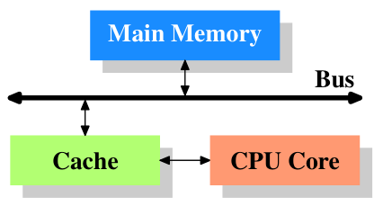

图3.1：最小缓存配置  
Figure 3.1: Minimum Cache Configuration

图3.1展示了最小的缓存配置。它对应于早期部署CPU缓存的系统中可以找到的架构。CPU内核不再直接连接到主存。<sup>16</sup>所有的加载和存储都必须经过缓存。CPU内核与缓存之间的连接是一条特殊的快速连接。在简化的表示中，主存和缓存连接到系统总线，系统总线也可以用于与系统的其他组件通信。我们曾把系统总线称为“FSB”，这是如今使用的名称；见2.2节。在本节中我们忽略北桥；假定它存在，以便CPU与主存之间的通信。

Figure 3.1 shows the minimum cache configuration. It corresponds to the architecture which could be found in early systems which deployed CPU caches. The CPU core is no longer directly connected to the main memory.<sup>16</sup> All loads and stores have to go through the cache. The connection between the CPU core and the cache is a special, fast connection. In a simplified representation, the main memory and the cache are connected to the system bus which can also be used for communication with other components of the system. We introduced the system bus as “FSB” which is the name in use today; see section 2.2. In this section we ignore the Northbridge; it is assumed to be present to facilitate the communication of the CPU(s) with the main memory.

尽管过去几十年来大多数计算机都使用[冯·诺依曼架构](http://en.wikipedia.org/wiki/Von_Neumann_architecture)，但经验表明，把用于代码和用于数据的缓存分开是有好处的。Intel从1993年起就使用分离的代码缓存和数据缓存，再也没有回头。代码和数据所需的内存区域彼此几乎是独立的，这就是独立的缓存效果更好的原因。近年来又出现了另一个优点：对于最常见的处理器，指令解码步骤很慢；缓存解码后的指令可以加快执行速度，尤其是当流水线因预测错误或无法预测的分支而变空时。

Even though most computers for the last several decades have used the [von Neumann architecture](http://en.wikipedia.org/wiki/Von_Neumann_architecture), experience has shown that it is of advantage to separate the caches used for code and for data. Intel has used separate code and data caches since 1993 and never looked back. The memory regions needed for code and data are pretty much independent of each other, which is why independent caches work better. In recent years another advantage emerged: the instruction decoding step for the most common processors is slow; caching decoded instructions can speed up the execution, especially when the pipeline is empty due to incorrectly predicted or impossible-to-predict branches.

缓存引入后不久，系统变得更加复杂。缓存与主存之间的速度差异再次扩大，以至于又增加了一级缓存，它比第一级缓存更大、更慢。出于经济原因，仅仅增大第一级缓存的大小是不可行的。如今，甚至有机器在常规使用中拥有三级缓存。带有这种处理器的系统如图3.2所示。随着单个CPU中内核数量的增加，未来缓存的级数可能还会增加。

Soon after the introduction of the cache the system got more complicated. The speed difference between the cache and the main memory increased again, to a point that another level of cache was added, bigger and slower than the first-level cache. Only increasing the size of the first-level cache was not an option for economical reasons. Today, there are even machines with three levels of cache in regular use. A system with such a processor looks like Figure 3.2. With the increase on the number of cores in a single CPU the number of cache levels might increase in the future even more.

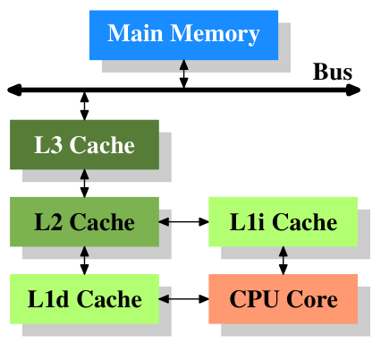

图3.2：带三级缓存的处理器  
Figure 3.2: Processor with Level 3 Cache

图3.2展示了三级缓存，并引入了本文其余部分将使用的命名法。L1d是一级数据缓存，L1i是一级指令缓存，等等。注意这只是一个示意图；在现实中，数据从内核到主存的流动不必经过任何更高级别的缓存。CPU设计者在设计缓存接口方面有很大的自由。对于程序员来说，这些设计选择是不可见的。

Figure 3.2 shows three levels of cache and introduces the nomenclature we will use in the remainder of the document. L1d is the level 1 data cache, L1i the level 1 instruction cache, etc. Note that this is a schematic; the data flow in reality need not pass through any of the higher-level caches on the way from the core to the main memory. CPU designers have a lot of freedom designing the interfaces of the caches. For programmers these design choices are invisible.

此外，我们还有拥有多个内核的处理器，每个内核可以有多个“线程”。内核与线程的区别在于，不同的内核拥有（几乎<sup>17</sup>）所有硬件资源的独立副本。除非同时使用相同的资源——例如对外的连接——否则各内核可以完全独立地运行。而线程则共享处理器的几乎所有资源。Intel的线程实现只为各线程提供了独立的寄存器，而且即便如此也是有限的，有些寄存器是共享的。因此，现代CPU的完整图景如图3.3所示。

In addition we have processors which have multiple cores and each core can have multiple “threads”. The difference between a core and a thread is that separate cores have separate copies of (almost<sup>17</sup>) all the hardware resources. The cores can run completely independently unless they are using the same resources–e.g., the connections to the outside–at the same time. Threads, on the other hand, share almost all of the processor’s resources. Intel’s implementation of threads has only separate registers for the threads and even that is limited, some registers are shared. The complete picture for a modern CPU therefore looks like Figure 3.3.

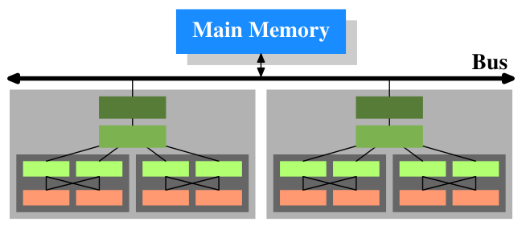

图3.3：多处理器、多核、多线程  
Figure 3.3: Multi processor, multi-core, multi-thread

在这幅图中，我们有两个处理器，每个处理器有两个内核，每个内核有两个线程。线程共享一级缓存。内核（以较深的灰色表示）拥有各自的一级缓存。CPU的所有内核共享更高级别的缓存。两个处理器（以较浅灰色表示的两个大方框）当然不共享任何缓存。所有这些都很重要，尤其是在我们讨论缓存对多进程和多线程应用程序的影响时。

In this figure we have two processors, each with two cores, each of which has two threads. The threads share the Level 1 caches. The cores (shaded in the darker gray) have individual Level 1 caches. All cores of the CPU share the higher-level caches. The two processors (the two big boxes shaded in the lighter gray) of course do not share any caches. All this will be important, especially when we are discussing the cache effects on multi-process and multi-thread applications.

### 3.2 高层次的缓存操作

### 3.2 Cache Operation at High Level

为了理解使用缓存的代价和节省，我们必须把第2节中关于机器架构和RAM技术的知识，与上一节描述的缓存结构结合起来。

To understand the costs and savings of using a cache we have to combine the knowledge about the machine architecture and RAM technology from section 2 with the structure of caches described in the previous section.

默认情况下，CPU内核读取或写入的所有数据都存储在缓存中。有些内存区域是不能被缓存的，但这只是操作系统实现者需要关心的事情；对应用程序员来说它是不可见的。也有一些指令允许程序员有意绕过某些缓存。这将在第6节中讨论。

By default all data read or written by the CPU cores is stored in the cache. There are memory regions which cannot be cached but this is something only the OS implementers have to be concerned about; it is not visible to the application programmer. There are also instructions which allow the programmer to deliberately bypass certain caches. This will be discussed in section 6.

如果CPU需要一个数据字，首先会搜索缓存。显然，缓存不可能包含整个主存的内容（否则我们就不需要缓存了），但由于所有内存地址都是可缓存的，每个缓存条目都用该数据字在主存中的地址加以*标记*。这样，读取或写入某个地址的请求就可以在缓存中搜索匹配的标记。在这里，地址可以是虚拟地址，也可以是物理地址，这取决于缓存的实现。

If the CPU needs a data word the caches are searched first. Obviously, the cache cannot contain the content of the entire main memory (otherwise we would need no cache), but since all memory addresses are cacheable, each cache entry is *tagged* using the address of the data word in the main memory. This way a request to read or write to an address can search the caches for a matching tag. The address in this context can be either the virtual or physical address, varying based on the cache implementation.

由于标记除了实际的内存之外还需要额外的空间，选择一个字作为缓存的粒度是低效的。对于x86机器上的一个32位字，标记本身可能就需要32位或更多。此外，由于空间局部性是缓存所依据的原则之一，不考虑这一点就不好了。由于相邻的内存很可能会被一起使用，它也应该被一起加载到缓存中。还请记住我们在2.2.1节中学到的：如果RAM模块可以在不需要新的CAS甚至RAS信号的情况下连续传输许多数据字，它们的效率就会高得多。因此，存储在缓存中的条目不是单个的字，而是由若干连续的字组成的“行”。在早期的缓存中，这些行长32字节；如今的标准是64字节。如果内存总线宽64位，这意味着每个缓存行需要8次传输。DDR能高效地支持这种传输模式。

Since for the tag, in addition to the actual memory, additional space is required, it is inefficient to chose a word as the granularity of the cache. For a 32-bit word on an x86 machine the tag itself might need 32 bits or more. Furthermore, since spatial locality is one of the principles on which caches are based, it would be bad to not take this into account. Since neighboring memory is likely to be used together it should also be loaded into the cache together. Remember also what we learned in section 2.2.1: RAM modules are much more effective if they can transport many data words in a row without a new CAS or even RAS signal. So the entries stored in the caches are not single words but, instead, “lines” of several contiguous words. In early caches these lines were 32 bytes long; nowadays the norm is 64 bytes. If the memory bus is 64 bits wide this means 8 transfers per cache line. DDR supports this transport mode efficiently.

当处理器需要内存内容时，整个缓存行都被加载到L1d中。每个缓存行的内存地址是通过根据缓存行大小对地址值进行掩码计算得出的。对于64字节的缓存行，这意味着低6位被清零。被丢弃的位用作缓存行内的偏移量。在某些情况下，其余的位被用来在缓存中定位该行，并用作标记。在实践中，一个地址值被分成三部分。对于32位地址，它可能如下所示：

When memory content is needed by the processor the entire cache line is loaded into the L1d. The memory address for each cache line is computed by masking the address value according to the cache line size. For a 64 byte cache line this means the low 6 bits are zeroed. The discarded bits are used as the offset into the cache line. The remaining bits are in some cases used to locate the line in the cache and as the tag. In practice an address value is split into three parts. For a 32-bit address it might look as follows:

| 31 |  |  | 0 |
| --- | --- | --- | --- |
| 标记 Tag |  | 缓存组 Cache Set | 偏移 Offset |
| T |  | S | O |

当缓存行大小为2<sup>**O**</sup>时，低**O**位用作缓存行内的偏移量。接下来的**S**位选择“缓存组”。我们很快就会更详细地说明为什么缓存行使用组而不是单个槽位。目前只需理解存在2<sup>**S**</sup>个缓存行组即可。剩下的最高32 − **S** − **O** = **T**位构成标记。这**T**位是与每个缓存行相关联的值，用于区分缓存在同一缓存组中的所有*别名*<sup>18</sup>。用于寻址缓存组的**S**位不必存储，因为同一组中所有缓存行的这些位都相同。

With a cache line size of 2<sup>**O**</sup> the low **O** bits are used as the offset into the cache line. The next **S** bits select the “cache set”. We will go into more detail soon on why sets, and not single slots, are used for cache lines. For now it is sufficient to understand there are 2<sup>**S**</sup> sets of cache lines. This leaves the top 32 − **S** − **O** = **T** bits which form the tag. These **T** bits are the value associated with each cache line to distinguish all the *aliases*<sup>18</sup> which are cached in the same cache set. The **S** bits used to address the cache set do not have to be stored since they are the same for all cache lines in the same set.

当一条指令修改内存时，处理器仍然必须先加载一个缓存行，因为没有指令会一次修改整个缓存行（规则的例外：写合并，见6.1节的解释）。因此，必须加载写操作之前的缓存行内容。缓存不可能保存部分缓存行。已被写入但尚未写回主存的缓存行被称为“脏的”。一旦写回，脏标志就被清除。

When an instruction modifies memory the processor still has to load a cache line first because no instruction modifies an entire cache line at once (exception to the rule: write-combining as explained in section 6.1). The content of the cache line before the write operation therefore has to be loaded. It is not possible for a cache to hold partial cache lines. A cache line which has been written to and which has not been written back to main memory is said to be “dirty”. Once it is written the dirty flag is cleared.

为了能在缓存中加载新数据，几乎总是必须先在缓存中腾出空间。从L1d中逐出会把缓存行推到L2中（L2使用相同的缓存行大小）。这当然意味着必须在L2中腾出空间。这又可能把内容推到L3，最终推到主存中。每一次逐出的代价都越来越高。这里描述的是现代AMD和VIA处理器所偏好的*独占式*缓存模型。Intel实现的是*包含式*缓存<sup>19</sup>，其中L1d中的每个缓存行也存在于L2中。因此从L1d中逐出要快得多。只要L2缓存足够大，在两个地方保存内容所浪费的内存就微不足道，并且在逐出时能带来回报。独占式缓存的一个可能优点是，加载一个新的缓存行只需触及L1d而不必触及L2，这可能更快。

To be able to load new data in a cache it is almost always first necessary to make room in the cache. An eviction from L1d pushes the cache line down into L2 (which uses the same cache line size). This of course means room has to be made in L2. This in turn might push the content into L3 and ultimately into main memory. Each eviction is progressively more expensive. What is described here is the model for an *exclusive* cache as is preferred by modern AMD and VIA processors. Intel implements *inclusive* caches<sup>19</sup> where each cache line in L1d is also present in L2. Therefore evicting from L1d is much faster. With enough L2 cache the disadvantage of wasting memory for content held in two places is minimal and it pays off when evicting. A possible advantage of an exclusive cache is that loading a new cache line only has to touch the L1d and not the L2, which could be faster.

只要不改变为处理器架构所定义的内存模型，CPU就可以随意管理缓存。例如，处理器利用内存总线活动很少或没有活动的时机，主动把脏的缓存行写回主存，是完全没有问题的。在x86和x86-64的处理器之间，在不同制造商之间，甚至在同一制造商的不同型号之间，缓存架构都千差万别，这正证明了内存模型抽象的威力。

The CPUs are allowed to manage the caches as they like as long as the memory model defined for the processor architecture is not changed. It is, for instance, perfectly fine for a processor to take advantage of little or no memory bus activity and proactively write dirty cache lines back to main memory. The wide variety of cache architectures among the processors for the x86 and x86-64, between manufacturers and even within the models of the same manufacturer, are testament to the power of the memory model abstraction.

在对称多处理器（SMP）系统中，各CPU的缓存不能彼此独立地工作。所有处理器都应当在任何时候看到相同的内存内容。维持这种一致的内存视图被称为“缓存一致性”。如果一个处理器只看自己的缓存和主存，它就看不到其他处理器中脏缓存行的内容。让一个处理器直接访问另一个处理器的缓存，代价将极其高昂，并且会成为巨大的瓶颈。取而代之的是，处理器会检测另一个处理器何时想要读取或写入某个缓存行。

In symmetric multi-processor (SMP) systems the caches of the CPUs cannot work independently from each other. All processors are supposed to see the same memory content at all times. The maintenance of this uniform view of memory is called “cache coherency”. If a processor were to look simply at its own caches and main memory it would not see the content of dirty cache lines in other processors. Providing direct access to the caches of one processor from another processor would be terribly expensive and a huge bottleneck. Instead, processors detect when another processor wants to read or write to a certain cache line.

如果检测到写访问，而处理器在其缓存中有该缓存行的干净副本，这个缓存行就被标记为无效。以后的引用将需要重新加载该缓存行。注意，另一个CPU上的读访问并不需要使缓存行无效，多个干净的副本完全可以同时保留。

If a write access is detected and the processor has a clean copy of the cache line in its cache, this cache line is marked invalid. Future references will require the cache line to be reloaded. Note that a read access on another CPU does not necessitate an invalidation, multiple clean copies can very well be kept around.

更复杂的缓存实现允许另一种可能。假设一个缓存行在一个处理器的缓存中是脏的，而第二个处理器想要读取或写入该缓存行。在这种情况下，主存是过时的，请求的处理器必须改为从第一个处理器那里获取缓存行的内容。通过*窥探*，第一个处理器注意到这种情况，并自动把数据发送给请求的处理器。这一操作绕过了主存，不过在某些实现中，内存控制器应当注意到这次直接传输，并把更新后的缓存行内容存储到主存中。如果访问是为了写入，第一个处理器随后会使其本地缓存行的副本无效。

More sophisticated cache implementations allow another possibility to happen. Assume a cache line is dirty in one processor’s cache and a second processor wants to read or write that cache line. In this case the main memory is out-of-date and the requesting processor must, instead, get the cache line content from the first processor. Through snooping, the first processor notices this situation and automatically sends the requesting processor the data. This action bypasses main memory, though in some implementations the memory controller is supposed to notice this direct transfer and store the updated cache line content in main memory. If the access is for writing the first processor then invalidates its copy of the local cache line.

随着时间的推移，人们开发了许多缓存一致性协议。其中最重要的是MESI，我们将在3.3.4节中介绍它。所有这一切的结果可以概括为几条简单的规则：

Over time a number of cache coherency protocols have been developed. The most important is MESI, which we will introduce in section 3.3.4. The outcome of all this can be summarized in a few simple rules:

- 脏的缓存行不会存在于任何其他处理器的缓存中。

  A dirty cache line is not present in any other processor’s cache.
- 同一缓存行的干净副本可以存在于任意多个缓存中。

  Clean copies of the same cache line can reside in arbitrarily many caches.

如果能维持这些规则，即使在多处理器系统中，处理器也能高效地使用它们的缓存。处理器所需要做的只是监视彼此的写访问，并把地址与其本地缓存中的地址进行比较。在下一节中，我们将更详细地讨论其实现，尤其是其代价。

If these rules can be maintained, processors can use their caches efficiently even in multi-processor systems. All the processors need to do is to monitor each others’ write accesses and compare the addresses with those in their local caches. In the next section we will go into a few more details about the implementation and especially the costs.

最后，我们至少应该对缓存命中和未命中的相关代价给出一个印象。以下是Intel为Pentium M列出的数字：

Finally, we should at least give an impression of the costs associated with cache hits and misses. These are the numbers Intel lists for a Pentium M:

| 访问目标 To Where | 周期数 Cycles |
| --- | --- |
| 寄存器 Register | ≤ 1 |
| L1d | ~3 |
| L2 | ~14 |
| 主存 Main Memory | ~240 |

这些是以CPU周期为单位测得的实际访问时间。值得注意的是，对于片上L2缓存，访问时间的很大一部分（甚至可能是大部分）是由线路延迟造成的。这是一种物理限制，只会随着缓存尺寸的增大而变得更糟。只有制程缩小（例如，在Intel的产品线中从Merom的60nm到Penryn的45nm）才能改善这些数字。

These are the actual access times measured in CPU cycles. It is interesting to note that for the on-die L2 cache a large part (probably even the majority) of the access time is caused by wire delays. This is a physical limitation which can only get worse with increasing cache sizes. Only process shrinking (for instance, going from 60nm for Merom to 45nm for Penryn in Intel’s lineup) can improve those numbers.

表中的数字看起来很高，但幸运的是，并不是每次发生缓存加载和未命中都必须支付全部代价。部分代价是可以被隐藏的。如今的处理器都使用长度不同的内部流水线，指令在其中被解码并为执行做准备。准备工作的一部分是：如果值要被传送到寄存器，就从内存（或缓存）中加载它们。如果内存加载操作能在流水线中足够早地启动，它就可能与其他操作并行发生，加载的全部代价就可能被隐藏。对于L1d，这通常是可能的；对于某些流水线较长的处理器，L2也是如此。

The numbers in the table look high but, fortunately, the entire cost does not have to be paid for each occurrence of the cache load and miss. Some parts of the cost can be hidden. Today’s processors all use internal pipelines of different lengths where the instructions are decoded and prepared for execution. Part of the preparation is loading values from memory (or cache) if they are transferred to a register. If the memory load operation can be started early enough in the pipeline, it may happen in parallel with other operations and the entire cost of the load might be hidden. This is often possible for L1d; for some processors with long pipelines for L2 as well.

提前开始内存读取有许多障碍。原因可能很简单，就是没有足够的资源来进行内存访问；也可能是加载的最终地址作为另一条指令的结果而较晚才可用。在这些情况下，加载的代价无法（完全）被隐藏。

There are many obstacles to starting the memory read early. It might be as simple as not having sufficient resources for the memory access or it might be that the final address of the load becomes available late as the result of another instruction. In these cases the load costs cannot be hidden (completely).

对于写操作，CPU不一定要等到值被安全地存储到内存中。只要后续指令的执行看起来与值已被存储到内存中具有相同的效果，就没有什么能阻止CPU走捷径。它可以提前开始执行下一条指令。借助影子寄存器——它们可以保存在普通寄存器中已不再可用的值——甚至可以修改在未完成的写操作中要存储的值。

For write operations the CPU does not necessarily have to wait until the value is safely stored in memory. As long as the execution of the following instructions appears to have the same effect as if the value were stored in memory there is nothing which prevents the CPU from taking shortcuts. It can start executing the next instruction early. With the help of shadow registers which can hold values no longer available in a regular register it is even possible to change the value which is to be stored in the incomplete write operation.

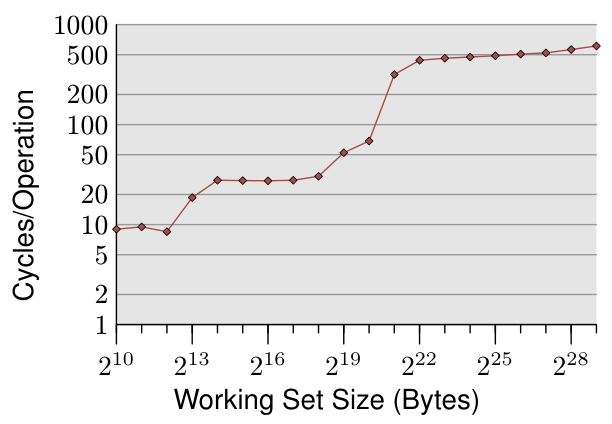

图3.4：随机写的访问时间  
Figure 3.4: Access Times for Random Writes

关于缓存行为影响的说明，请参见图3.4。我们稍后会讨论生成这些数据的程序；它是对一个程序的简单模拟，该程序以随机方式反复访问一块大小可配置的内存。每个数据项的大小是固定的。元素的数量取决于所选的工作集大小。Y轴显示处理一个元素平均所需的CPU周期数；注意Y轴的刻度是对数的。在所有这类图表中，X轴也是如此。工作集的大小总是以2的幂表示。

For an illustration of the effects of cache behavior see Figure 3.4. We will talk about the program which generated the data later; it is a simple simulation of a program which accesses a configurable amount of memory repeatedly in a random fashion. Each data item has a fixed size. The number of elements depends on the selected working set size. The Y–axis shows the average number of CPU cycles it takes to process one element; note that the scale for the Y–axis is logarithmic. The same applies in all the diagrams of this kind to the X–axis. The size of the working set is always shown in powers of two.

该图显示出三个明显的平台。这并不奇怪：这个特定的处理器有L1d和L2缓存，但没有L3。凭借一些经验我们可以推断，L1d的大小为2<sup>13</sup>字节，L2的大小为2<sup>20</sup>字节。如果整个工作集都能放进L1d，处理每个元素的周期数低于10。一旦超出L1d的大小，处理器就必须从L2加载数据，平均时间跃升到28左右。一旦L2也不够用了，时间就跳到480个周期及以上。这时许多或大部分操作都必须从主存加载数据。更糟的是：由于数据正在被修改，脏的缓存行也必须被写回。

The graph shows three distinct plateaus. This is not surprising: the specific processor has L1d and L2 caches, but no L3. With some experience we can deduce that the L1d is 2<sup>13</sup> bytes in size and that the L2 is 2<sup>20</sup> bytes in size. If the entire working set fits into the L1d the cycles per operation on each element is below 10. Once the L1d size is exceeded the processor has to load data from L2 and the average time springs up to around 28. Once the L2 is not sufficient anymore the times jump to 480 cycles and more. This is when many or most operations have to load data from main memory. And worse: since data is being modified dirty cache lines have to be written back, too.

这张图应该足以激发人们去研究有助于改善缓存使用的编码改进。我们说的不是区区几个百分点的差别；我们说的是有时可能实现的数量级上的改进。在第6节中，我们将讨论能够写出更高效代码的技术。下一节将更详细地讨论CPU缓存的设计。了解这些知识是有益的，但对于本文的其余部分并非必需。因此可以跳过这一节。

This graph should give sufficient motivation to look into coding improvements which help improve cache usage. We are not talking about a difference of a few measly percent here; we are talking about orders-of-magnitude improvements which are sometimes possible. In section 6 we will discuss techniques which allow writing more efficient code. The next section goes into more details of CPU cache designs. The knowledge is good to have but not necessary for the rest of the paper. So this section could be skipped.

### 3.3 CPU缓存的实现细节

### 3.3 CPU Cache Implementation Details

缓存实现者面临这样一个问题：庞大主存中的每一个单元都有可能需要被缓存。如果一个程序的工作集足够大，这意味着有许多主存位置在争夺缓存中的每一个位置。前面提到过，缓存与主存大小之比为1比1000并不罕见。

Cache implementers have the problem that each cell in the huge main memory potentially has to be cached. If the working set of a program is large enough this means there are many main memory locations which fight for each place in the cache. Previously it was noted that a ratio of 1-to-1000 for cache versus main memory size is not uncommon.

#### 3.3.1 相联度

#### 3.3.1 Associativity

可以实现这样一种缓存：其中每个缓存行都可以保存任何内存位置的副本（见图3.5）。这被称为*全相联缓存*。要访问一个缓存行，处理器内核必须把每一个缓存行的标记与所请求地址的标记进行比较。标记将由地址中不属于缓存行内偏移量的全部部分组成（这意味着第15页图中的**S**为零）。

It would be possible to implement a cache where each cache line can hold a copy of any memory location (see Figure 3.5). This is called a *fully associative cache*. To access a cache line the processor core would have to compare the tags of each and every cache line with the tag for the requested address. The tag would be comprised of the entire part of the address which is not the offset into the cache line (that means, **S** in the figure on page 15 is zero).

确实有以这种方式实现的缓存，但看看如今使用的L2的数字就会发现这是不切实际的。给定一个缓存行为64B的4MB缓存，该缓存将有65,536个条目。为了达到足够的性能，缓存逻辑必须能在短短几个周期内，从所有这些条目中挑出与给定标记相匹配的那一个。实现这一点所需的工作量将是巨大的。

There are caches which are implemented like this but, by looking at the numbers for an L2 in use today, will show that this is impractical. Given a 4MB cache with 64B cache lines the cache would have 65,536 entries. To achieve adequate performance the cache logic would have to be able to pick from all these entries the one matching a given tag in just a few cycles. The effort to implement this would be enormous.

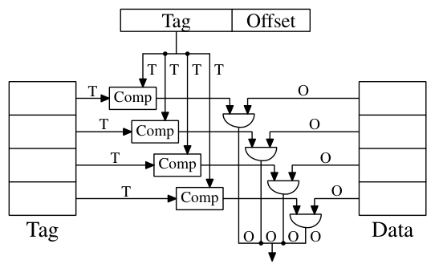

图3.5：全相联缓存原理图  
Figure 3.5: Fully Associative Cache Schematics

对于每个缓存行，都需要一个比较器来比较那个很大的标记（注意，**S**为零）。每条连线旁边的字母表示以位为单位的宽度。如果没有标注，则是单比特线路。每个比较器都必须比较两个**T**位宽的值。然后，根据比较结果，选出相应的缓存行内容并使其可用。这需要合并与缓存桶数量一样多的**O**条数据线组。实现单个比较器所需的晶体管数量很大，尤其因为它必须工作得非常快。迭代比较器是不能用的。节省比较器数量的唯一方法是通过迭代比较标记来减少比较器的数量。这同样不适用，原因与迭代比较器不适用的原因相同：它需要的时间太长了。

For each cache line a comparator is needed to compare the large tag (note, **S** is zero). The letter next to each connection indicates the width in bits. If none is given it is a single bit line. Each comparator has to compare two **T**-bit-wide values. Then, based on the result, the appropriate cache line content is selected and made available. This requires merging as many sets of **O** data lines as there are cache buckets. The number of transistors needed to implement a single comparator is large especially since it must work very fast. No iterative comparator is usable. The only way to save on the number of comparators is to reduce the number of them by iteratively comparing the tags. This is not suitable for the same reason that iterative comparators are not: it takes too long.

全相联缓存对于小型缓存是可行的（例如，某些Intel处理器上的TLB缓存就是全相联的），但那些缓存很小，真的很小。我们说的是最多几十个条目。

Fully associative caches are practical for small caches (for instance, the TLB caches on some Intel processors are fully associative) but those caches are small, really small. We are talking about a few dozen entries at most.

对于L1i、L1d以及更高级别的缓存，需要一种不同的方法。可以做的是限制搜索范围。在最极端的限制下，每个标记恰好映射到一个缓存条目。计算很简单：对于有65,536个条目的4MB/64B缓存，我们可以使用地址的第6到第21位（16位）直接寻址每个条目。低6位是缓存行内的索引。

For L1i, L1d, and higher level caches a different approach is needed. What can be done is to restrict the search. In the most extreme restriction each tag maps to exactly one cache entry. The computation is simple: given the 4MB/64B cache with 65,536 entries we can directly address each entry by using bits 6 to 21 of the address (16 bits). The low 6 bits are the index into the cache line.

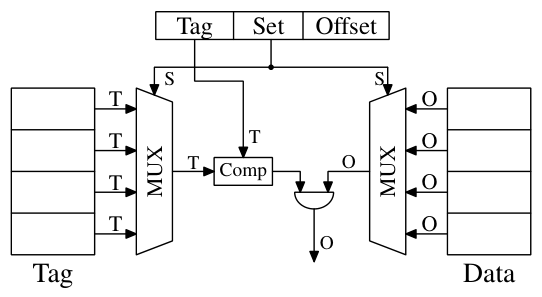

图3.6：直接映射缓存原理图  
Figure 3.6: Direct-Mapped Cache Schematics

如图3.6所示，这样的*直接映射缓存*速度快，而且相对容易实现。它恰好需要一个比较器、一个复用器（在这张图中有两个，因为标记和数据是分开的，但这并不是对设计的硬性要求），以及一些只选择有效缓存行内容的逻辑。由于速度要求，比较器很复杂，但现在只有一个；因此可以投入更多精力使它变快。这种方法真正的复杂性在于复用器。一个简单复用器中的晶体管数量以O(log N)增长，其中N是缓存行的数量。这是可以容忍的，但可能会变慢，在这种情况下，可以在复用器中花费更多的芯片面积用于晶体管，把部分工作并行化以提高速度。随着缓存大小的增长，晶体管总数可以缓慢增长，这使得这种方案非常有吸引力。但它有一个缺点：只有当程序使用的地址相对于用于直接映射的那些位是均匀分布时，它才能很好地工作。如果不是这样（而通常就不是这样），一些缓存条目会被频繁使用，因而被反复逐出，而另一些则几乎不被使用或一直是空的。

Such a *direct-mapped cache* is fast and relatively easy to implement as can be seen in Figure 3.6. It requires exactly one comparator, one multiplexer (two in this diagram where tag and data are separated, but this is not a hard requirement on the design), and some logic to select only valid cache line content. The comparator is complex due to the speed requirements but there is only one of them now; as a result more effort can be spent on making it fast. The real complexity in this approach lies in the multiplexers. The number of transistors in a simple multiplexer grows with O(log N), where N is the number of cache lines. This is tolerable but might get slow, in which case speed can be increased by spending more real estate on transistors in the multiplexers to parallelize some of the work and to increase the speed. The total number of transistors can grow slowly with a growing cache size which makes this solution very attractive. But it has a drawback: it only works well if the addresses used by the program are evenly distributed with respect to the bits used for the direct mapping. If they are not, and this is usually the case, some cache entries are heavily used and therefore repeated evicted while others are hardly used at all or remain empty.

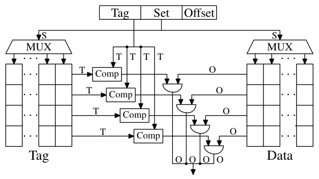

图3.7：组相联缓存原理图  
Figure 3.7: Set-Associative Cache Schematics

这个问题可以通过使缓存成为*组相联*的来解决。组相联缓存结合了全相联缓存和直接映射缓存的优点，在很大程度上避免了这两种设计的弱点。图3.7展示了组相联缓存的设计。标记和数据存储被划分为若干组，其中一组由缓存行的地址选中。这与直接映射缓存类似。但对于缓存中的每个组值，不是只有一个元素，而是为同一组值缓存少量的值。所有组成员的标记被并行比较，这与全相联缓存的工作方式类似。

This problem can be solved by making the cache *set associative*. A set-associative cache combines the good features of the full associative and direct-mapped caches to largely avoid the weaknesses of those designs. Figure 3.7 shows the design of a set-associative cache. The tag and data storage are divided into sets, one of which is selected by the address of a cache line. This is similar to the direct-mapped cache. But instead of only having one element for each set value in the cache a small number of values is cached for the same set value. The tags for all the set members are compared in parallel, which is similar to the functioning of the fully associative cache.

其结果是一种不容易被不幸地——或蓄意地——选择具有相同组号的地址所击败的缓存，同时缓存的大小也不受能够经济地实现的比较器数量的限制。如果缓存变大，（在这张图中）增加的只是列数，而不是行数。只有在提高缓存的相联度时，行数（以及比较器的数量）才会增加。如今的处理器对L2缓存使用高达24或更高的相联度。L1缓存通常只需8路组相联即可。

The result is a cache which is not easily defeated by unfortunate–or deliberate–selection of addresses with the same set numbers and at the same time the size of the cache is not limited by the number of comparators which can be implemented economically. If the cache grows it is (in this figure) only the number of columns which increases, not the number of rows. The number of rows (and therefore comparators) only increases if the associativity of the cache is increased. Today processors are using associativity levels of up to 24 for L2 caches or higher. L1 caches usually get by with 8 sets.

| 缓存大小 Cache Size | L2相联度 L2 Associativity 直接映射 Direct CL=32 | L2相联度 L2 Associativity 直接映射 Direct CL=64 | L2相联度 L2 Associativity 2路 2 CL=32 | L2相联度 L2 Associativity 2路 2 CL=64 | L2相联度 L2 Associativity 4路 4 CL=32 | L2相联度 L2 Associativity 4路 4 CL=64 | L2相联度 L2 Associativity 8路 8 CL=32 | L2相联度 L2 Associativity 8路 8 CL=64 |
| --- | --- | --- | --- | --- | --- | --- | --- | --- |
| 512k | 27,794,595 | 20,422,527 | 25,222,611 | 18,303,581 | 24,096,510 | 17,356,121 | 23,666,929 | 17,029,334 |
| 1M | 19,007,315 | 13,903,854 | 16,566,738 | 12,127,174 | 15,537,500 | 11,436,705 | 15,162,895 | 11,233,896 |
| 2M | 12,230,962 | 8,801,403 | 9,081,881 | 6,491,011 | 7,878,601 | 5,675,181 | 7,391,389 | 5,382,064 |
| 4M | 7,749,986 | 5,427,836 | 4,736,187 | 3,159,507 | 3,788,122 | 2,418,898 | 3,430,713 | 2,125,103 |
| 8M | 4,731,904 | 3,209,693 | 2,690,498 | 1,602,957 | 2,207,655 | 1,228,190 | 2,111,075 | 1,155,847 |
| 16M | 2,620,587 | 1,528,592 | 1,958,293 | 1,089,580 | 1,704,878 | 883,530 | 1,671,541 | 862,324 |

表3.1：缓存大小、相联度和缓存行大小的影响  
Table 3.1: Effects of Cache Size, Associativity, and Line Size

对于我们的4MB/64B缓存和8路组相联，我们得到的缓存有8,192个组，并且只有13位标记用于寻址缓存组。要确定缓存组中的哪个条目（如果有的话）包含被寻址的缓存行，必须比较8个标记。这在很短的时间内是可以做到的。通过实验我们可以看到这样做是有道理的。

Given our 4MB/64B cache and 8-way set associativity the cache we are left with has 8,192 sets and only 13 bits of the tag are used in addressing the cache set. To determine which (if any) of the entries in the cache set contains the addressed cache line 8 tags have to be compared. That is feasible to do in very short time. With an experiment we can see that this makes sense.

表3.1显示了一个程序（这里是gcc，根据Linux内核开发者的说法，它是所有基准测试中最重要的一个）在改变缓存大小、缓存行大小和相联组大小时的L2缓存未命中次数。在7.2节中，我们将介绍为该测试模拟缓存所需的工具。

Table 3.1 shows the number of L2 cache misses for a program (gcc in this case, the most important benchmark of them all, according to the Linux kernel people) for changing cache size, cache line size, and associativity set size. In section 7.2 we will introduce the tool to simulate the caches as required for this test.

以防这一点还不够明显，所有这些值之间的关系是：缓存大小为

Just in case this is not yet obvious, the relationship of all these values is that the cache size is

$$cache line size×associativity×number of sets$$

地址按照第15页的图所示的方式映射到缓存中，使用

The addresses are mapped into the cache by using

$$O=log2 cache line sizeS=log2 number of sets$$

图3.8使表中的数据更易于理解。它显示了缓存行大小固定为32字节时的数据。观察给定缓存大小的数字，我们可以看到相联度确实能显著减少缓存未命中的次数。对于8MB缓存，从直接映射变为2路组相联缓存，节省了几乎44%的缓存未命中。与直接映射缓存相比，使用组相联缓存时处理器可以在缓存中保留更多的工作集。

Figure 3.8 makes the data of the table more comprehensible. It shows the data for a fixed cache line size of 32 bytes. Looking at the numbers for a given cache size we can see that associativity can indeed help to reduce the number of cache misses significantly. For an 8MB cache going from direct mapping to 2-way set associative cache saves almost 44% of the cache misses. The processor can keep more of the working set in the cache with a set associative cache compared with a direct mapped cache.

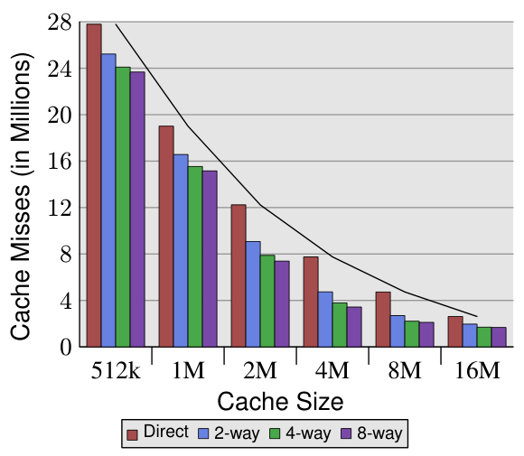

图3.8：缓存大小与相联度（CL=32）  
Figure 3.8: Cache Size vs Associativity (CL=32)  
图例：Direct=直接映射，2-way/4-way/8-way=2/4/8路组相联。

在文献中，人们偶尔会读到：引入相联度与把缓存大小加倍有相同的效果。在一些极端情况下这是对的，正如从4MB到8MB缓存的跳变中可以看到的那样。但对于进一步把相联度加倍，这肯定是不对的。正如我们在数据中看到的，后续的收益要小得多。不过，我们也不应完全忽视这些效果。在示例程序中，内存使用峰值为5.6M。因此对于8MB缓存，同一缓存组不太可能有很多次（超过两次）使用。对于更大的工作集，节省可以更多，正如我们从较小缓存大小下相联度带来的更大收益中所看到的那样。

In the literature one can occasionally read that introducing associativity has the same effect as doubling cache size. This is true in some extreme cases as can be seen in the jump from the 4MB to the 8MB cache. But it certainly is not true for further doubling of the associativity. As we can see in the data, the successive gains are much smaller. We should not completely discount the effects, though. In the example program the peak memory use is 5.6M. So with a 8MB cache there are unlikely to be many (more than two) uses for the same cache set. With a larger working set the savings can be higher as we can see from the larger benefits of associativity for the smaller cache sizes.

一般来说，对于单线程工作负载，把缓存的相联度提高到8以上似乎效果甚微。随着第一级缓存被共享的超线程处理器、以及使用共享L2缓存的多核处理器的出现，情况发生了变化。现在基本上是两个程序在冲击同一个缓存，这使得相联度在实践中减半（对于四核处理器则减为四分之一）。因此可以预期，随着内核数量的增加，共享缓存的相联度应当随之增长。一旦这不再可能（16路组相联已经很难实现了），处理器设计者就必须开始使用共享的L3缓存乃至更高级别的缓存，而L2缓存则可能由一部分内核共享。

In general, increasing the associativity of a cache above 8 seems to have little effects for a single-threaded workload. With the introduction of hyper-threaded processors where the first level cache is shared and multi-core processors which use a shared L2 cache the situation changes. Now you basically have two programs hitting on the same cache which causes the associativity in practice to be halved (or quartered for quad-core processors). So it can be expected that, with increasing numbers of cores, the associativity of the shared caches should grow. Once this is not possible anymore (16-way set associativity is already hard) processor designers have to start using shared L3 caches and beyond, while L2 caches are potentially shared by a subset of the cores.

我们可以在图3.8中研究的另一个效果是缓存大小的增加如何有助于性能。如果不知道工作集的大小，就无法解释这些数据。显然，一个与主存一样大的缓存会比较小的缓存带来更好的结果，因此一般来说，能带来可测量收益的最大缓存大小是没有上限的。

Another effect we can study in Figure 3.8 is how the increase in cache size helps with performance. This data cannot be interpreted without knowing about the working set size. Obviously, a cache as large as the main memory would lead to better results than a smaller cache, so there is in general no limit to the largest cache size with measurable benefits.

正如上面已经提到的，工作集在峰值时的大小为5.6M。这并没有给出最大有益缓存大小的任何绝对数字，但它让我们可以估计这个数字。问题在于，所使用的内存并不全是连续的，因此即使使用16M缓存和5.6M工作集，我们仍然会遇到冲突（见2路组相联16MB缓存相对于直接映射版本的优势）。但可以有把握地说，对于同样的工作负载，32MB缓存带来的收益将微乎其微。但谁说工作集必须保持不变呢？工作负载随时间增长，缓存大小也应随之增长。在购买机器、必须选择愿意为之付费的缓存大小时，测量一下工作集大小是值得的。为什么这很重要，可以从第21页的图中看出。

As already mentioned above, the size of the working set at its peak is 5.6M. This does not give us any absolute number of the maximum beneficial cache size but it allows us to estimate the number. The problem is that not all the memory used is contiguous and, therefore, we have, even with a 16M cache and a 5.6M working set, conflicts (see the benefit of the 2-way set associative 16MB cache over the direct mapped version). But it is a safe bet that with the same workload the benefits of a 32MB cache would be negligible. But who says the working set has to stay the same? Workloads are growing over time and so should the cache size. When buying machines, and one has to choose the cache size one is willing to pay for, it is worthwhile to measure the working set size. Why this is important can be seen in the figures on page 21.

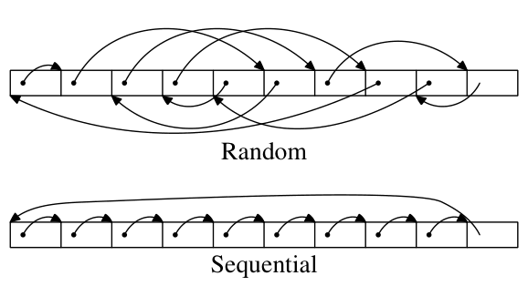

图3.9：测试的内存布局  
Figure 3.9: Test Memory Layouts  
Random=随机，Sequential=顺序。

我们运行了两类测试。在第一种测试中，元素按顺序处理。测试程序沿着指针`n`前进，但数组元素是这样链接起来的：它们按照在内存中出现的顺序被遍历。这可以在图3.9的下半部分看到。从最后一个元素有一个回指。在第二种测试中（图的上半部分），数组元素以随机顺序遍历。在这两种情况下，数组元素都构成一个循环单链表。

Two types of tests are run. In the first test the elements are processed sequentially. The test program follows the pointer `n` but the array elements are chained so that they are traversed in the order in which they are found in memory. This can be seen in the lower part of Figure 3.9. There is one back reference from the last element. In the second test (upper part of the figure) the array elements are traversed in a random order. In both cases the array elements form a circular single-linked list.

#### 3.3.2 缓存效应的测量

#### 3.3.2 Measurements of Cache Effects

所有的图都是通过测量一个程序而得到的，该程序可以模拟任意大小的工作集、读访问和写访问，以及顺序访问或随机访问。我们已经在图3.4中看到了一些结果。该程序创建一个与工作集大小相对应的数组，其元素为如下类型：

All the figures are created by measuring a program which can simulate working sets of arbitrary size, read and write access, and sequential or random access. We have already seen some results in Figure 3.4. The program creates an array corresponding to the working set size of elements of this type:

```c
struct l {
  struct l *n;
  long int pad[NPAD];
};
```

所有条目都通过`n`元素以顺序或随机的次序链接成一个循环链表。即使元素是按顺序排列的，从一个条目前进到下一个条目也总是使用指针。`pad`元素是有效载荷，它可以任意增大。在某些测试中数据会被修改，在另一些测试中程序只执行读操作。

All entries are chained in a circular list using the `n` element, either in sequential or random order. Advancing from one entry to the next always uses the pointer, even if the elements are laid out sequentially. The `pad` element is the payload and it can grow arbitrarily large. In some tests the data is modified, in others the program only performs read operations.

在性能测量中，我们谈论的是工作集大小。工作集由一个`struct l`元素数组组成。一个2<sup>N</sup>字节的工作集包含2<sup>N</sup>/sizeof(struct l)个元素。显然，sizeof(struct l)取决于NPAD的值。对于32位系统，NPAD=7意味着每个数组元素的大小为32字节，对于64位系统则为64字节。

In the performance measurements we are talking about working set sizes. The working set is made up of an array of `struct l` elements. A working set of 2<sup>N</sup> bytes contains 2<sup>N</sup>/sizeof(struct l) elements. Obviously sizeof(struct l) depends on the value of NPAD. For 32-bit systems, NPAD=7 means the size of each array element is 32 bytes, for 64-bit systems the size is 64 bytes.

##### 单线程顺序访问

##### Single Threaded Sequential Access

最简单的情况是对链表中所有条目的一次简单遍历。链表元素按顺序紧密排列。处理的顺序是向前还是向后并不重要，处理器可以同样好地应对两个方向。我们在这里——以及在接下来所有的测试中——所测量的，是处理单个链表元素需要多长时间。时间单位是处理器周期。图3.10显示了结果。除非另有说明，所有测量都是在一台64位模式下的Pentium 4机器上进行的，这意味着NPAD=0的结构`l`大小为八字节。

The simplest case is a simple walk over all the entries in the list. The list elements are laid out sequentially, densely packed. Whether the order of processing is forward or backward does not matter, the processor can deal with both directions equally well. What we measure here–and in all the following tests–is how long it takes to handle a single list element. The time unit is a processor cycle. Figure 3.10 shows the result. Unless otherwise specified, all measurements are made on a Pentium 4 machine in 64-bit mode which means the structure `l` with NPAD=0 is eight bytes in size.

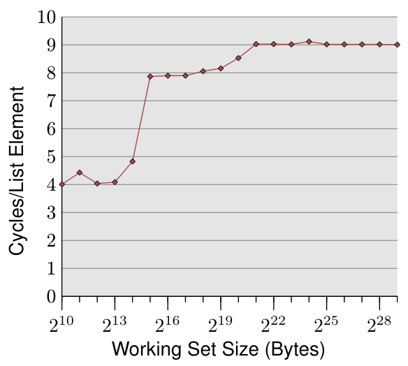

图3.10：顺序读访问，NPAD=0  
Figure 3.10: Sequential Read Access, NPAD=0

前两个测量值受到噪声的污染。所测量的工作负载实在太小，无法滤除系统其余部分的影响。我们可以有把握地假设这些值都在4个周期的水平上。考虑到这一点，我们可以看到三个明显的水平：

The first two measurements are polluted by noise. The measured workload is simply too small to filter the effects of the rest of the system out. We can safely assume that the values are all at the 4 cycles level. With this in mind we can see three distinct levels:

- 工作集大小最多到2<sup>14</sup>字节。

  Up to a working set size of 2<sup>14</sup> bytes.
- 从2<sup>15</sup>字节到2<sup>20</sup>字节。

  From 2<sup>15</sup> bytes to 2<sup>20</sup> bytes.
- 从2<sup>21</sup>字节及以上。

  From 2<sup>21</sup> bytes and up.

这些台阶很容易解释：该处理器有16kB的L1d和1MB的L2。我们在从一个水平到另一个水平的过渡中看不到清晰的边缘，因为缓存也被系统的其他部分使用，因此缓存并不是专供程序数据使用的。具体来说，L2缓存是一个统一缓存，也用于指令（注：Intel使用包含式缓存）。

These steps can be easily explained: the processor has a 16kB L1d and 1MB L2. We do not see sharp edges in the transition from one level to the other because the caches are used by other parts of the system as well and so the cache is not exclusively available for the program data. Specifically the L2 cache is a unified cache and also used for the instructions (NB: Intel uses inclusive caches).

或许不太符合预期的是不同工作集大小下的实际时间。L1d命中的时间是符合预期的：在P4上，L1d命中后的加载时间约为4个周期。但L2访问呢？一旦L1d不足以容纳数据，人们可能会预期每个元素需要14个周期或更多，因为这是L2的访问时间。但结果显示只需要大约9个周期。这一差异可以用处理器中的高级逻辑来解释。由于预期会使用连续的内存区域，处理器会预取下一个缓存行。这意味着当下一行实际被使用时，它已经加载了一半。因此等待下一个缓存行加载所需的延迟要比L2访问时间短得多。

What is perhaps not quite expected are the actual times for the different working set sizes. The times for the L1d hits are expected: load times after an L1d hit are around 4 cycles on the P4. But what about the L2 accesses? Once the L1d is not sufficient to hold the data one might expect it would take 14 cycles or more per element since this is the access time for the L2. But the results show that only about 9 cycles are required. This discrepancy can be explained by the advanced logic in the processors. In anticipation of using consecutive memory regions, the processor prefetches the next cache line. This means that when the next line is actually used it is already halfway loaded. The delay required to wait for the next cache line to be loaded is therefore much less than the L2 access time.

一旦工作集大小超过L2的大小，预取的效果就更加明显了。前面我们说过，一次主存访问需要200多个周期。只有通过有效的预取，处理器才可能把访问时间保持在低至9个周期。从200和9之间的差异可以看出，这一机制运作得很好。

The effect of prefetching is even more visible once the working set size grows beyond the L2 size. Before we said that a main memory access takes 200+ cycles. Only with effective prefetching is it possible for the processor to keep the access times as low as 9 cycles. As we can see from the difference between 200 and 9, this works out nicely.

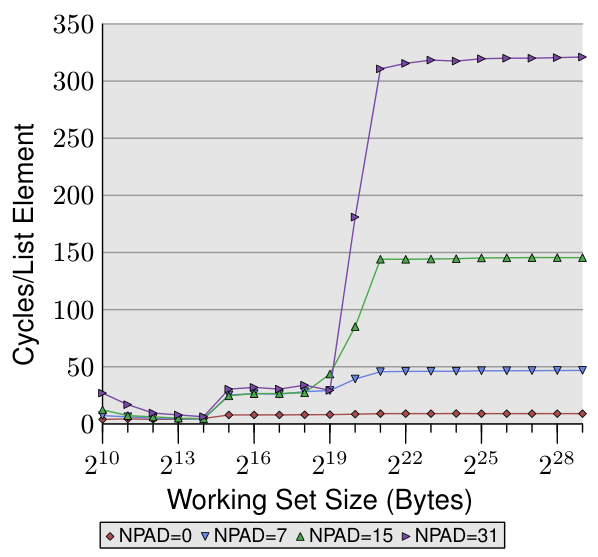

图3.11：几种大小下的顺序读  
Figure 3.11: Sequential Read for Several Sizes

我们可以观察处理器的预取，至少是间接地观察。在图3.11中，我们看到的是相同工作集大小下的时间，但这一次我们看到的是结构`l`不同大小时的曲线。这意味着链表中的元素更少但更大。不同的大小导致（仍然连续的）链表中`n`元素之间的距离增大。在图中的四种情况下，这一距离分别为0、56、120和248字节。

We can observe the processor while prefetching, at least indirectly. In Figure 3.11 we see the times for the same working set sizes but this time we see the graphs for different sizes of the structure `l`. This means we have fewer but larger elements in the list. The different sizes have the effect that the distance between the `n` elements in the (still consecutive) list grows. In the four cases of the graph the distance is 0, 56, 120, and 248 bytes respectively.

在底部我们可以看到图3.10中的那条线，但这一次它看起来或多或少是一条平坦的线。其他情况下的时间实在差得太多了。在这张图中我们同样可以看到三个不同的水平，也可以看到小工作集的测试中误差很大（同样忽略它们）。只要只涉及L1d，这些线或多或少都彼此吻合。不需要预取，因此每次访问时所有元素大小都只是命中L1d。

At the bottom we can see the line from Figure 3.10, but this time it appears more or less as a flat line. The times for the other cases are simply so much worse. We can see in this graph, too, the three different levels and we see the large errors in the tests with the small working set sizes (ignore them again). The lines more or less all match each other as long as only the L1d is involved. There is no prefetching necessary so all element sizes just hit the L1d for each access.

对于L2缓存命中，我们看到三条新的线几乎彼此吻合，但它们处于更高的水平（大约28）。这正是L2访问时间的水平。这意味着从L2到L1d的预取基本上被禁用了。即使NPAD=7，我们在循环的每次迭代中也需要一个新的缓存行；而对于NPAD=0，循环要迭代八次才需要下一个缓存行。预取逻辑不可能每个周期都加载一个新的缓存行。因此我们看到每次迭代都会因从L2加载而停顿。

For the L2 cache hits we see that the three new lines all pretty much match each other but that they are at a higher level (about 28). This is the level of the access time for the L2. This means prefetching from L2 into L1d is basically disabled. Even with NPAD=7 we need a new cache line for each iteration of the loop; for NPAD=0, instead, the loop has to iterate eight times before the next cache line is needed. The prefetch logic cannot load a new cache line every cycle. Therefore we see a stall to load from L2 in every iteration.

一旦工作集大小超过L2的容量，情况就变得更加有趣了。现在四条线差异巨大。不同的元素大小在性能差异中显然起着很大的作用。处理器应当识别出步长的大小，并且对于NPAD=15和31不去获取不必要的缓存行，因为元素大小小于预取窗口（见6.3.1节）。元素大小妨碍预取工作的地方，是硬件预取的一个限制造成的：它不能跨越页边界。每增加一次大小，我们就使硬件调度器的有效性降低50%。如果允许硬件预取器跨越页边界，而下一页不驻留或无效，那么操作系统将不得不介入定位该页。这意味着程序会遇到一个并非它自己引发的缺页。这是完全不可接受的，因为处理器不知道一个页面是不存在于内存中还是根本不存在。在后一种情况下，操作系统将不得不终止该进程。无论如何，鉴于对于NPAD=7及更大的值，我们每个链表元素都需要一个缓存行，硬件预取器就无能为力了。根本没有时间从内存加载数据，因为处理器所做的只是读一个字然后加载下一个元素。

It gets even more interesting once the working set size exceeds the L2 capacity. Now all four lines vary widely. The different element sizes play obviously a big role in the difference in performance. The processor should recognize the size of the strides and not fetch unnecessary cache lines for NPAD=15 and 31 since the element size is smaller than the prefetch window (see section 6.3.1). Where the element size is hampering the prefetching efforts is a result of a limitation of hardware prefetching: it cannot cross page boundaries. We are reducing the effectiveness of the hardware scheduler by 50% for each size increase. If the hardware prefetcher were allowed to cross page boundaries and the next page is not resident or valid the OS would have to get involved in locating the page. That means the program would experience a page fault it did not initiate itself. This is completely unacceptable since the processor does not know whether a page is not present or does not exist. In the latter case the OS would have to abort the process. In any case, given that, for NPAD=7 and higher, we need one cache line per list element the hardware prefetcher cannot do much. There simply is no time to load the data from memory since all the processor does is read one word and then load the next element.

变慢的另一个重要原因是TLB缓存的未命中。这是一个存储虚拟地址到物理地址转换结果的缓存，第4节将对此作更详细的解释。TLB缓存相当小，因为它必须极快。如果被反复访问的页数多于TLB缓存的条目数，从虚拟地址到物理地址的转换就必须不断重复。这是一个代价非常高的操作。元素越大，TLB查找的代价被分摊到的元素就越少。这意味着每个链表元素需要计算的TLB条目总数就越多。

Another big reason for the slowdown are the misses of the TLB cache. This is a cache where the results of the translation of a virtual address to a physical address are stored, as is explained in more detail in section 4. The TLB cache is quite small since it has to be extremely fast. If more pages are accessed repeatedly than the TLB cache has entries for the translation from virtual to physical address has to be constantly repeated. This is a very costly operation. With larger element sizes the cost of a TLB lookup is amortized over fewer elements. That means the total number of TLB entries which have to be computed per list element is higher.

为了观察TLB的效应，我们可以运行一个不同的测试。在一次测量中，我们照常顺序排列元素。我们使用NPAD=7，使每个元素占据一整个缓存行。在第二次测量中，我们把每个链表元素放在一个单独的页面上。每页的其余部分保持不动，我们也不把它计入工作集大小的总数中。<sup>20</sup>其结果是，在第一次测量中，每次链表迭代都需要一个新的缓存行，并且每64个元素需要一个新的页面。在第二次测量中，每次迭代都需要加载一个位于新页面上的新缓存行。

To observe the TLB effects we can run a different test. For one measurement we lay out the elements sequentially as usual. We use NPAD=7 for elements which occupy one entire cache line. For the second measurement we place each list element on a separate page. The rest of each page is left untouched and we do not count it in the total for the working set size.<sup>20</sup> The consequence is that, for the first measurement, each list iteration requires a new cache line and, for every 64 elements, a new page. For the second measurement each iteration requires loading a new cache line which is on a new page.

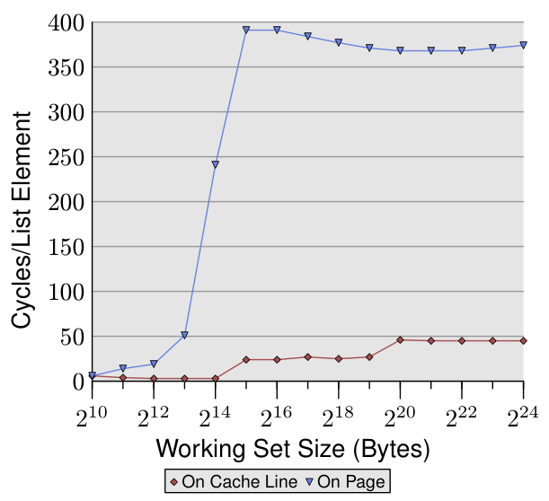

图3.12：TLB对顺序读的影响  
Figure 3.12: TLB Influence for Sequential Read  
On Cache Line=按缓存行，On Page=按页。

结果可以在图3.12中看到。测量是在与图3.11相同的机器上进行的。由于可用RAM的限制，工作集大小必须限制在2<sup>24</sup>字节，这需要1GB来把对象放在单独的页面上。较低的红色曲线与图3.11中的NPAD=7曲线完全对应。我们看到了显示L1d和L2缓存大小的明显台阶。第二条曲线看起来截然不同。重要的特征是，从工作集大小达到2<sup>13</sup>字节开始出现的巨大尖峰。这就是TLB缓存溢出的时候。元素大小为64字节时，我们可以计算出TLB缓存有64个条目。不存在影响代价的缺页，因为程序锁定了内存以防止其被换出。

The result can be seen in Figure 3.12. The measurements were performed on the same machine as Figure 3.11. Due to limitations of the available RAM the working set size had to be restricted to 2<sup>24</sup> bytes which requires 1GB to place the objects on separate pages. The lower, red curve corresponds exactly to the NPAD=7 curve in Figure 3.11. We see the distinct steps showing the sizes of the L1d and L2 caches. The second curve looks radically different. The important feature is the huge spike starting when the working set size reaches 2<sup>13</sup> bytes. This is when the TLB cache overflows. With an element size of 64 bytes we can compute that the TLB cache has 64 entries. There are no page faults affecting the cost since the program locks the memory to prevent it from being swapped out.

可以看到，计算物理地址并将其存储到TLB中所需的周期数非常高。图3.12中的图显示的是极端情况，但现在应当清楚，对于较大的NPAD值，变慢的一个重要因素是TLB缓存效率的降低。由于在为L2或主存读取缓存行之前必须计算出物理地址，地址转换的代价是叠加在内存访问时间之上的。这在一定程度上解释了为什么NPAD=31时每个链表元素的总代价高于RAM的理论访问时间。

As can be seen the number of cycles it takes to compute the physical address and store it in the TLB is very high. The graph in Figure 3.12 shows the extreme case, but it should now be clear that a significant factor in the slowdown for larger NPAD values is the reduced efficiency of the TLB cache. Since the physical address has to be computed before a cache line can be read for either L2 or main memory the address translation penalties are additive to the memory access times. This in part explains why the total cost per list element for NPAD=31 is higher than the theoretical access time for the RAM.

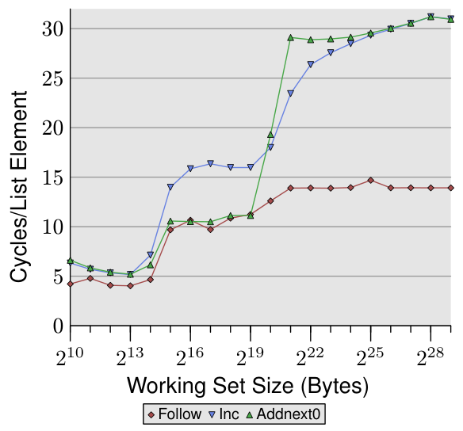

图3.13：顺序读与写，NPAD=1  
Figure 3.13: Sequential Read and Write, NPAD=1  
Follow=跟随，Inc=加一，Addnext0=加下一个元素的pad[0]。

通过查看修改链表元素的测试运行数据，我们可以瞥见预取实现的更多细节。图3.13显示了三条线。在所有情况下，元素宽度都是16字节。第一条线是现在已经熟悉的链表遍历，作为基线。第二条线标为“Inc”，它只是在前进到下一个元素之前，把当前元素的`pad[0]`成员加一。第三条线标为“Addnext0”，它取出下一个元素的`pad[0]`，并把它加到当前链表元素的`pad[0]`成员上。

We can glimpse a few more details of the prefetch implementation by looking at the data of test runs where the list elements are modified. Figure 3.13 shows three lines. The element width is in all cases 16 bytes. The first line is the now familiar list walk which serves as a baseline. The second line, labeled “Inc”, simply increments the `pad[0]` member of the current element before going on to the next. The third line, labeled “Addnext0”, takes the `pad[0]` list element of the next element and adds it to the `pad[0]` member of the current list element.

天真的假设是，“Addnext0”测试运行得更慢，因为它要做更多的工作。在前进到下一个链表元素之前，必须先加载该元素中的一个值。这就是为什么看到这个测试在某些工作集大小下实际上比“Inc”测试运行得*更快*会令人惊讶。对此的解释是，从下一个链表元素的加载基本上是一次强制预取。每当程序前进到下一个链表元素时，我们可以确定该元素已经在L1d缓存中了。因此我们看到，只要工作集大小能放进L2缓存，“Addnext0”的表现就与简单的“Follow”测试一样好。

The naïve assumption would be that the “Addnext0” test runs slower because it has more work to do. Before advancing to the next list element a value from that element has to be loaded. This is why it is surprising to see that this test actually runs, for some working set sizes, faster than the “Inc” test. The explanation for this is that the load from the next list element is basically a forced prefetch. Whenever the program advances to the next list element we know for sure that element is already in the L1d cache. As a result we see that the “Addnext0” performs as well as the simple “Follow” test as long as the working set size fits into the L2 cache.

不过，“Addnext0”测试比“Inc”测试更早地耗尽L2。它需要从主存加载更多的数据。这就是为什么“Addnext0”测试在工作集大小为2<sup>21</sup>字节时达到了28个周期的水平。28个周期的水平是“Follow”测试所达到的14个周期水平的两倍。这也很容易解释。由于另外两个测试会修改内存，为新缓存行腾出空间的L2缓存逐出不能简单地丢弃数据。相反，数据必须被写回内存。这意味着FSB上的可用带宽被减半，因此把数据从主存传输到L2所需的时间加倍。

The “Addnext0” test runs out of L2 faster than the “Inc” test, though. It needs more data loaded from main memory. This is why the “Addnext0” test reaches the 28 cycles level for a working set size of 2<sup>21</sup> bytes. The 28 cycles level is twice as high as the 14 cycles level the “Follow” test reaches. This is easy to explain, too. Since the other two tests modify memory an L2 cache eviction to make room for new cache lines cannot simply discard the data. Instead it has to be written to memory. This means the available bandwidth on the FSB is cut in half, hence doubling the time it takes to transfer the data from main memory to L2.

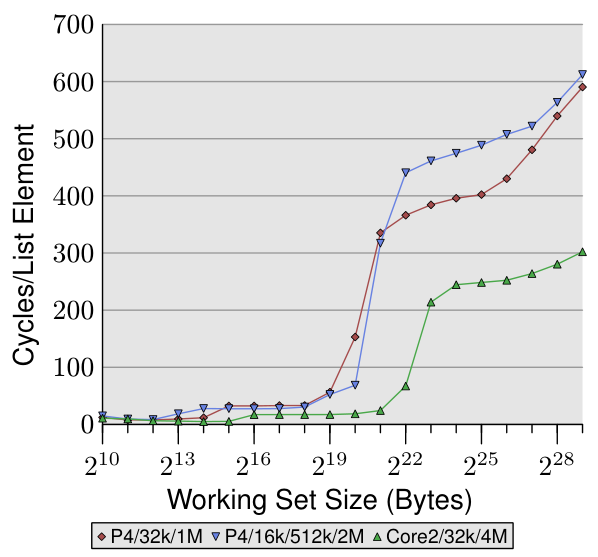

图3.14：更大L2/L3缓存的优势  
Figure 3.14: Advantage of Larger L2/L3 Caches

顺序的、高效的缓存处理的最后一个方面是缓存的大小。这应该是显而易见的，但仍然值得指出。图3.14显示了使用128字节元素（在64位机器上NPAD=15）的Increment基准测试的时间。这一次我们看到来自三台不同机器的测量结果。前两台机器是P4，最后一台是Core2处理器。前两台的区别在于缓存大小不同。第一个处理器有32k L1d和1M L2。第二个有16k L1d、512k L2和2M L3。Core2处理器有32k L1d和4M L2。

One last aspect of the sequential, efficient cache handling is the size of the cache. This should be obvious but it still should be pointed out. Figure 3.14 shows the timing for the Increment benchmark with 128-byte elements (NPAD=15 on 64-bit machines). This time we see the measurement from three different machines. The first two machines are P4s, the last one a Core2 processor. The first two differentiate themselves by having different cache sizes. The first processor has a 32k L1d and an 1M L2. The second one has 16k L1d, 512k L2, and 2M L3. The Core2 processor has 32k L1d and 4M L2.

这张图有趣的地方并不一定在于Core2处理器相对于另外两个处理器的表现有多好（尽管它令人印象深刻）。这里主要的关注点在于这样一个区域：工作集大小对于各自的最后一级缓存来说太大了，主存因此被大量卷入。

The interesting part of the graph is not necessarily how well the Core2 processor performs relative to the other two (although it is impressive). The main point of interest here is the region where the working set size is too large for the respective last level cache and the main memory gets heavily involved.

正如预期的那样，最后一级缓存越大，曲线在对应于L2访问代价的低水平上停留的时间就越长。需要注意的重要部分是这带来的性能优势。第二个处理器（稍旧一些）在2<sup>20</sup>字节的工作集上完成工作的速度是第一个处理器的两倍。这完全要归功于增大的最后一级缓存。拥有4M L2的Core2处理器表现得更好。

As expected, the larger the last level cache is the longer the curve stays at the low level corresponding to the L2 access costs. The important part to notice is the performance advantage this provides. The second processor (which is slightly older) can perform the work on the working set of 2<sup>20</sup> bytes twice as fast as the first processor. All thanks to the increased last level cache size. The Core2 processor with its 4M L2 performs even better.

对于随机的工作负载，这可能意义不大。但如果工作负载可以根据最后一级缓存的大小进行调整，程序的性能就能相当显著地提高。这就是为什么有时值得多花些钱购买缓存更大的处理器。

For a random workload this might not mean that much. But if the workload can be tailored to the size of the last level cache the program performance can be increased quite dramatically. This is why it sometimes is worthwhile to spend the extra money for a processor with a larger cache.

##### 单线程随机访问

##### Single Threaded Random Access

我们已经看到，通过把缓存行预取到L2和L1d中，处理器能够隐藏大部分主存乃至L2的访问延迟。不过，这只有在内存访问可预测时才能很好地发挥作用。

We have seen that the processor is able to hide most of the main memory and even L2 access latency by prefetching cache lines into L2 and L1d. This can work well only when the memory access is predictable, though.

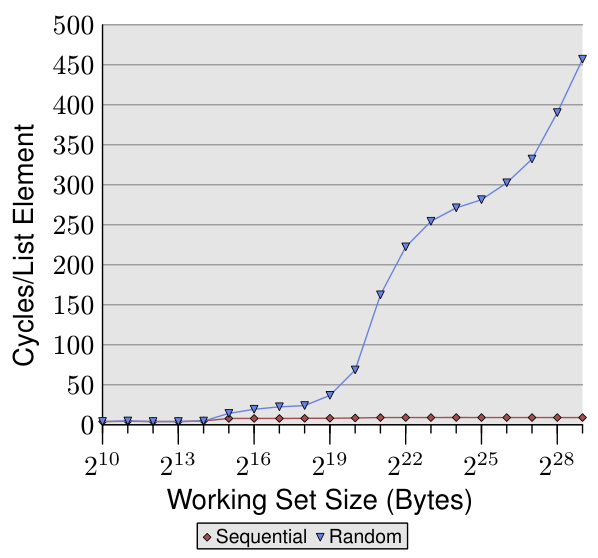

图3.15：顺序读与随机读，NPAD=0  
Figure 3.15: Sequential vs Random Read, NPAD=0  
Sequential=顺序，Random=随机。

如果访问模式不可预测或是随机的，情况就大不相同了。图3.15把顺序访问时（与图3.10相同）每个链表元素的时间，与链表元素在工作集中随机分布时的时间进行了比较。顺序由随机化的链表决定。处理器无法可靠地预取数据。只有当紧接着使用的元素在内存中也彼此靠近时，预取才可能碰巧起作用。

If the access pattern is unpredictable or random the situation is quite different. Figure 3.15 compares the per-list-element times for the sequential access (same as in Figure 3.10) with the times when the list elements are randomly distributed in the working set. The order is determined by the linked list which is randomized. There is no way for the processor to reliably prefetch data. This can only work by chance if elements which are used shortly after one another are also close to each other in memory.

图3.15中有两点值得注意。第一点是随着工作集增大所需的周期数很多。这台机器可以在200–300个周期内访问主存，但这里我们达到了450个周期甚至更多。我们之前已经见过这种现象（比较图3.11）。自动预取在这里实际上起了反作用。

There are two important points to note in Figure 3.15. The first is the large number of cycles needed for growing working set sizes. The machine makes it possible to access the main memory in 200-300 cycles but here we reach 450 cycles and more. We have seen this phenomenon before (compare Figure 3.11). The automatic prefetching is actually working to a disadvantage here.

第二个有趣的点是，这条曲线并没有像顺序访问的情况那样在不同的平台上变平。曲线不断上升。为了解释这一点，我们可以测量程序在不同工作集大小下的L2访问情况。结果可以在图3.16和表3.2中看到。

The second interesting point is that the curve is not flattening at various plateaus as it has been for the sequential access cases. The curve keeps on rising. To explain this we can measure the L2 access of the program for the various working set sizes. The result can be seen in Figure 3.16 and Table 3.2.

该图显示，当工作集大小大于L2大小时，缓存未命中率（L2访问次数/L2未命中次数）开始增长。这条曲线与图3.15中的曲线形状相似：迅速上升，略微下降，然后再次开始上升。它与每链表元素周期数的图有很强的相关性。L2未命中率将一直增长，直到最终接近100%。给定足够大的工作集（以及RAM），随机挑选的任意缓存行位于L2中或正在被加载的概率可以被任意降低。

The figure shows that, when the working set size is larger than the L2 size, the cache miss ratio (L2 accesses / L2 misses) starts to grow. The curve has a similar form to the one in Figure 3.15: it rises quickly, declines slightly, and starts to rise again. There is a strong correlation with the cycles per list element graph. The L2 miss rate will grow until it eventually reaches close to 100%. Given a large enough working set (and RAM) the probability that any of the randomly picked cache lines is in L2 or is in the process of being loaded can be reduced arbitrarily.

| 工作集大小 Set Size | 顺序 Sequential L2命中 L2 Hit | 顺序 Sequential L2未命中 L2 Miss | 顺序 Sequential #迭代 #Iter | 顺序 Sequential 未命中/命中比 Ratio Miss/Hit | 顺序 Sequential 每次迭代L2访问 L2 Accesses per Iteration | 随机 Random L2命中 L2 Hit | 随机 Random L2未命中 L2 Miss | 随机 Random #迭代 #Iter | 随机 Random 未命中/命中比 Ratio Miss/Hit | 随机 Random 每次迭代L2访问 L2 Accesses per Iteration |
| --- | --- | --- | --- | --- | --- | --- | --- | --- | --- | --- |
| 2<sup>20</sup> | 88,636 | 843 | 16,384 | 0.94% | 5.5 | 30,462 | 4721 | 1,024 | 13.42% | 34.4 |
| 2<sup>21</sup> | 88,105 | 1,584 | 8,192 | 1.77% | 10.9 | 21,817 | 15,151 | 512 | 40.98% | 72.2 |
| 2<sup>22</sup> | 88,106 | 1,600 | 4,096 | 1.78% | 21.9 | 22,258 | 22,285 | 256 | 50.03% | 174.0 |
| 2<sup>23</sup> | 88,104 | 1,614 | 2,048 | 1.80% | 43.8 | 27,521 | 26,274 | 128 | 48.84% | 420.3 |
| 2<sup>24</sup> | 88,114 | 1,655 | 1,024 | 1.84% | 87.7 | 33,166 | 29,115 | 64 | 46.75% | 973.1 |
| 2<sup>25</sup> | 88,112 | 1,730 | 512 | 1.93% | 175.5 | 39,858 | 32,360 | 32 | 44.81% | 2,256.8 |
| 2<sup>26</sup> | 88,112 | 1,906 | 256 | 2.12% | 351.6 | 48,539 | 38,151 | 16 | 44.01% | 5,418.1 |
| 2<sup>27</sup> | 88,114 | 2,244 | 128 | 2.48% | 705.9 | 62,423 | 52,049 | 8 | 45.47% | 14,309.0 |
| 2<sup>28</sup> | 88,120 | 2,939 | 64 | 3.23% | 1,422.8 | 81,906 | 87,167 | 4 | 51.56% | 42,268.3 |
| 2<sup>29</sup> | 88,137 | 4,318 | 32 | 4.67% | 2,889.2 | 119,079 | 163,398 | 2 | 57.84% | 141,238.5 |

表3.2：顺序遍历与随机遍历的L2命中与未命中，NPAD=0  
Table 3.2: L2 Hits and Misses for Sequential and Random Walks, NPAD=0

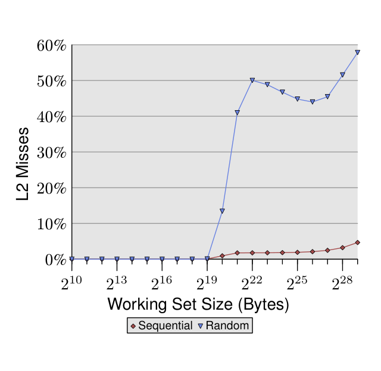

图3.16：L2d未命中率  
Figure 3.16: L2d Miss Ratio  
Sequential=顺序，Random=随机。

仅仅缓存未命中率的增加就解释了部分代价。但还有另一个因素。观察表3.2，我们可以在L2/#Iter列中看到，程序每次迭代对L2的使用总次数在增长。每个工作集都是前一个的两倍大。因此，在没有缓存的情况下，我们预期主存访问次数会加倍。有了缓存和（几乎）完美的可预测性，我们在顺序访问的数据中看到L2使用量的增加很温和。这种增加完全是由于工作集大小的增加，而不是别的原因。

The increasing cache miss rate alone explains some of the costs. But there is another factor. Looking at Table 3.2 we can see in the L2/#Iter columns that the total number of L2 uses per iteration of the program is growing. Each working set is twice as large as the one before. So, without caching we would expect double the main memory accesses. With caches and (almost) perfect predictability we see the modest increase in the L2 use shown in the data for sequential access. The increase is due to the increase of the working set size and nothing else.

对于随机访问，工作集大小每加倍一次，每个元素的访问时间就增加一倍以上。这意味着每个链表元素的平均访问时间在增加，因为工作集大小只是加倍。其背后的原因是TLB未命中率的上升。在图3.17中我们看到NPAD=7时随机访问的代价。只是这一次随机化的方式被修改了。在通常的情况下，整个链表作为一个块被随机化（用标签∞表示），而其他11条曲线显示的是在较小的块中进行的随机化。对于标为“60”的曲线，每组60个页面（245.760字节）被单独随机化。这意味着块中的所有链表元素都被遍历完之后，才会转到下一个块中的元素。其效果是在任一时刻使用的TLB条目数量是有限的。

For random access the per-element access time more than doubles for each doubling of the working set size. This means the average access time per list element increases since the working set size only doubles. The reason behind this is a rising rate of TLB misses. In Figure 3.17 we see the cost for random accesses for NPAD=7. Only this time the randomization is modified. While in the normal case the entire list of randomized as one block (indicated by the label ∞) the other 11 curves show randomizations which are performed in smaller blocks. For the curve labeled ‘60’ each set of 60 pages (245.760 bytes) is randomized individually. That means all list elements in the block are traversed before going over to an element in the next block. This has the effect that number of TLB entries which are used at any one time is limited.

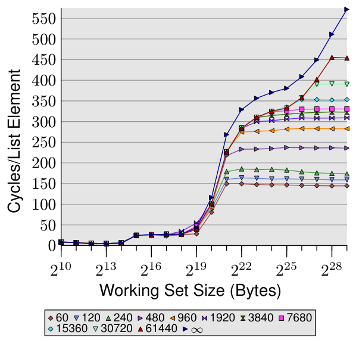

图3.17：按页随机化，NPAD=7  
Figure 3.17: Page-Wise Randomization, NPAD=7

NPAD=7时的元素大小为64字节，正好对应缓存行大小。由于链表元素的随机顺序，硬件预取器不太可能起任何作用，对于超过少数几个元素的情况更是肯定不会。这意味着L2缓存未命中率与整个链表在一个块中随机化时没有显著差异。随着块大小的增加，测试的性能渐近地趋向于单块随机化的曲线。这意味着后一种测试情形的性能受到TLB未命中的显著影响。如果能降低TLB未命中，性能就会显著提高（在我们稍后将看到的一个测试中，提高可达38%）。

The element size for NPAD=7 is 64 bytes, which corresponds to the cache line size. Due to the randomized order of the list elements it is unlikely that the hardware prefetcher has any effect, most certainly not for more than a handful of elements. This means the L2 cache miss rate does not differ significantly from the randomization of the entire list in one block. The performance of the test with increasing block size approaches asymptotically the curve for the one-block randomization. This means the performance of this latter test case is significantly influenced by the TLB misses. If the TLB misses can be lowered the performance increases significantly (in one test we will see later up to 38%).

#### 3.3.3 写行为

#### 3.3.3 Write Behavior

在我们开始研究多个执行上下文（线程或进程）使用同一内存时的缓存行为之前，我们必须探讨缓存实现的一个细节。缓存应当是一致的，并且这种一致性对用户级代码应当是完全透明的。内核代码则是另一回事；它偶尔需要刷新缓存。

Before we start looking at the cache behavior when multiple execution contexts (threads or processes) use the same memory we have to explore a detail of cache implementations. Caches are supposed to be coherent and this coherency is supposed to be completely transparent for the userlevel code. Kernel code is a different story; it occasionally requires cache flushes.

这具体意味着，如果一个缓存行被修改，那么在此时刻之后，对系统而言的结果与根本没有缓存、而是主存位置本身被修改的情况相同。这可以通过两种方式或策略来实现：

This specifically means that, if a cache line is modified, the result for the system after this point in time is the same as if there were no cache at all and the main memory location itself had been modified. This can be implemented in two ways or policies:

- 直写式缓存实现；

  write-through cache implementation;
- 回写式缓存实现。

  write-back cache implementation.

直写式缓存是实现缓存一致性最简单的方法。如果缓存行被写入，处理器会立即也把该缓存行写入主存。这确保了主存和缓存在任何时候都是同步的。每当一个缓存行被替换时，缓存内容都可以简单地被丢弃。这种缓存策略简单但不太快。例如，一个反复修改局部变量的程序，即使这些数据很可能不在其他任何地方使用并且可能是短暂的，也会在FSB上产生大量流量。

The write-through cache is the simplest way to implement cache coherency. If the cache line is written to, the processor immediately also writes the cache line into main memory. This ensures that, at all times, the main memory and cache are in sync. The cache content could simply be discarded whenever a cache line is replaced. This cache policy is simple but not very fast. A program which, for instance, modifies a local variable over and over again would create a lot of traffic on the FSB even though the data is likely not used anywhere else and might be short-lived.

回写策略更为复杂。在这里，处理器不会立即把修改过的缓存行写回主存。相反，缓存行只是被标记为脏的。当缓存行在将来某个时刻被从缓存中丢弃时，脏位会指示处理器在那时把数据写回，而不是仅仅丢弃内容。

The write-back policy is more sophisticated. Here the processor does not immediately write the modified cache line back to main memory. Instead, the cache line is only marked as dirty. When the cache line is dropped from the cache at some point in the future the dirty bit will instruct the processor to write the data back at that time instead of just discarding the content.

回写式缓存有可能显著地表现得更好，这就是为什么在配有像样处理器的系统中，大部分内存都以这种方式缓存。处理器甚至可以利用FSB上的空闲容量，在缓存行必须被腾出之前就存储其内容。这使得脏位可以被清除，处理器在需要缓存空间时就可以直接丢弃该缓存行。

Write-back caches have the chance to be significantly better performing, which is why most memory in a system with a decent processor is cached this way. The processor can even take advantage of free capacity on the FSB to store the content of a cache line before the line has to be evacuated. This allows the dirty bit to be cleared and the processor can just drop the cache line when the room in the cache is needed.

但回写式实现有一个重大问题。当有不止一个处理器（或内核、超线程）可用并访问同一内存时，仍然必须保证两个处理器在任何时候都看到相同的内存内容。如果一个缓存行在一个处理器上是脏的（即尚未写回），而第二个处理器试图读取同一内存位置，读操作就不能直接去主存。相反，需要第一个处理器缓存行的内容。在下一节中，我们将看到这一点目前是如何实现的。

But there is a significant problem with the write-back implementation. When more than one processor (or core or hyper-thread) is available and accessing the same memory it must still be assured that both processors see the same memory content at all times. If a cache line is dirty on one processor (i.e., it has not been written back yet) and a second processor tries to read the same memory location, the read operation cannot just go out to the main memory. Instead the content of the first processor’s cache line is needed. In the next section we will see how this is currently implemented.

在讨论这一点之前，还有两种缓存策略需要提及：

Before we get to this there are two more cache policies to mention:

- 写合并；以及

  write-combining; and
- 不可缓存。

  uncacheable.

这两种策略都用于地址空间中不由真实RAM支持的特殊区域。内核为这些地址范围设置这些策略（在x86处理器上使用内存类型范围寄存器，MTRR），其余的事情就自动发生了。MTRR也可用于在直写和回写策略之间进行选择。

Both these policies are used for special regions of the address space which are not backed by real RAM. The kernel sets up these policies for the address ranges (on x86 processors using the Memory Type Range Registers, MTRRs) and the rest happens automatically. The MTRRs are also usable to select between write-through and write-back policies.

写合并是一种有限的缓存优化，更常用于显卡等设备上的RAM。由于传输到设备的代价比访问本地RAM高得多，避免进行过多传输就更加重要。如果下一个操作会修改下一个字，那么仅仅因为行中的一个字被写入就传输整个缓存行是一种浪费。很容易想象这是常见的情况，屏幕上水平相邻像素的内存在大多数情况下也是相邻的。顾名思义，写合并会在缓存行被写出之前把多次写访问合并起来。在理想情况下，整个缓存行被逐字修改，只有在最后一个字被写入之后，缓存行才被写到设备。这可以显著加快对设备上RAM的访问。

Write-combining is a limited caching optimization more often used for RAM on devices such as graphics cards. Since the transfer costs to the devices are much higher than the local RAM access it is even more important to avoid doing too many transfers. Transferring an entire cache line just because a word in the line has been written is wasteful if the next operation modifies the next word. One can easily imagine that this is a common occurrence, the memory for horizontal neighboring pixels on a screen are in most cases neighbors, too. As the name suggests, write-combining combines multiple write accesses before the cache line is written out. In ideal cases the entire cache line is modified word by word and, only after the last word is written, the cache line is written to the device. This can speed up access to RAM on devices significantly.

最后是不可缓存的内存。这通常意味着该内存位置根本不由RAM支持。它可能是一个特殊地址，被硬编码为具有在CPU之外实现的某种功能。对于通用硬件，最常见的情况是内存映射的地址范围，对它们的访问会被转换为对连接在总线（PCIe等）上的卡和设备的访问。在嵌入式电路板上，人们有时会发现可以用来开关LED的内存地址。缓存这样的地址显然是个坏主意。在这种情况下，LED用于调试或状态报告，人们希望尽快看到它。PCIe卡上的内存可以在没有CPU参与的情况下发生变化，因此这种内存不应被缓存。

Finally there is uncacheable memory. This usually means the memory location is not backed by RAM at all. It might be a special address which is hardcoded to have some functionality implemented outside the CPU. For commodity hardware this most often is the case for memory mapped address ranges which translate to accesses to cards and devices attached to a bus (PCIe etc). On embedded boards one sometimes finds such a memory address which can be used to turn an LED on and off. Caching such an address would obviously be a bad idea. LEDs in this context are used for debugging or status reports and one wants to see this as soon as possible. The memory on PCIe cards can change without the CPU’s interaction, so this memory should not be cached.

#### 3.3.4 多处理器支持

#### 3.3.4 Multi-Processor Support

在上一节中，我们已经指出了多个处理器参与时我们面临的问题。即使是多核处理器，对于那些不共享的缓存级别（至少是L1d）也存在这个问题。

In the previous section we have already pointed out the problem we have when multiple processors come into play. Even multi-core processors have the problem for those cache levels which are not shared (at least the L1d).

让一个处理器直接访问另一个处理器的缓存是完全不切实际的。首先，连接根本不够快。切实可行的替代方案是在需要时把缓存内容传送给另一个处理器。注意，这也适用于同一处理器上不共享的缓存。

It is completely impractical to provide direct access from one processor to the cache of another processor. The connection is simply not fast enough, for a start. The practical alternative is to transfer the cache content over to the other processor in case it is needed. Note that this also applies to caches which are not shared on the same processor.

现在的问题是：这种缓存行传输必须在什么时候发生？这个问题很容易回答：当一个处理器为了读或写而需要一个在另一个处理器缓存中是脏的缓存行时。但处理器如何确定一个缓存行在另一个处理器的缓存中是否是脏的呢？仅仅因为一个缓存行被另一个处理器加载过就作此假设，（往好了说）也是次优的。通常大多数内存访问都是读访问，由此产生的缓存行也不是脏的。处理器对缓存行的操作非常频繁（当然了，不然我们为什么要写这篇文章？），这意味着在每次写访问之后广播关于被修改缓存行的信息是不切实际的。

The question now is when does this cache line transfer have to happen? This question is pretty easy to answer: when one processor needs a cache line which is dirty in another processor’s cache for reading or writing. But how can a processor determine whether a cache line is dirty in another processor’s cache? Assuming it just because a cache line is loaded by another processor would be suboptimal (at best). Usually the majority of memory accesses are read accesses and the resulting cache lines are not dirty. Processor operations on cache lines are frequent (of course, why else would we have this paper?) which means broadcasting information about changed cache lines after each write access would be impractical.

多年来发展起来的是MESI缓存一致性协议（Modified修改、Exclusive独占、Shared共享、Invalid无效）。该协议以使用MESI协议时缓存行可能处于的四种状态命名：

What developed over the years is the MESI cache coherency protocol (Modified, Exclusive, Shared, Invalid). The protocol is named after the four states a cache line can be in when using the MESI protocol:

**修改（Modified） Modified**

本地处理器已经修改了该缓存行。这也意味着它是所有缓存中唯一的副本。

The local processor has modified the cache line. This also implies it is the only copy in any cache.

**独占（Exclusive） Exclusive**

该缓存行未被修改，但已知没有被加载到任何其他处理器的缓存中。

The cache line is not modified but known to not be loaded into any other processor’s cache.

**共享（Shared） Shared**

该缓存行未被修改，并且可能存在于另一个处理器的缓存中。

The cache line is not modified and might exist in another processor’s cache.

**无效（Invalid） Invalid**

该缓存行无效，即未被使用。

The cache line is invalid, i.e., unused.

这个协议是多年来从一些不那么复杂、但效率也更低的较简单版本发展而来的。有了这四种状态，就可以高效地实现回写式缓存，同时也支持在不同处理器上并发使用只读数据。

This protocol developed over the years from simpler versions which were less complicated but also less efficient. With these four states it is possible to efficiently implement write-back caches while also supporting concurrent use of read-only data on different processors.

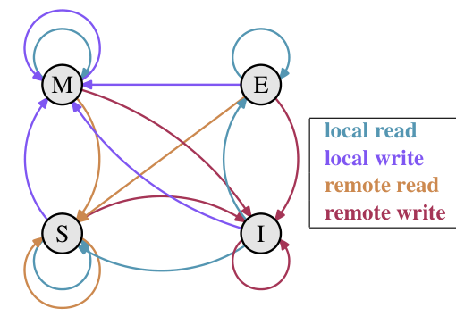

图3.18：MESI协议状态转换  
Figure 3.18: MESI Protocol Transitions  
local read=本地读，local write=本地写，remote read=远程读，remote write=远程写。

状态的改变是通过处理器监听（或窥探）其他处理器的工作而实现的，并不需要太多额外的工作。处理器执行的某些操作会在外部引脚上公布，从而使处理器的缓存处理对外部可见。相关缓存行的地址在地址总线上是可见的。在下面对状态及其转换（如图3.18所示）的描述中，我们将指出何时涉及总线。

The state changes are accomplished without too much effort by the processors listening, or snooping, on the other processors’ work. Certain operations a processor performs are announced on external pins and thus make the processor’s cache handling visible to the outside. The address of the cache line in question is visible on the address bus. In the following description of the states and their transitions (shown in Figure 3.18) we will point out when the bus is involved.

最初，所有缓存行都是空的，因此也是无效的。如果为了写入而把数据加载到缓存中，缓存行变为修改状态。如果为了读取而加载数据，新状态取决于另一个处理器是否也加载了该缓存行。如果是，新状态为共享，否则为独占。

Initially all cache lines are empty and hence also Invalid. If data is loaded into the cache for writing the cache changes to Modified. If the data is loaded for reading the new state depends on whether another processor has the cache line loaded as well. If this is the case then the new state is Shared, otherwise Exclusive.

如果在本地处理器上读取或写入一个修改状态的缓存行，指令可以使用当前的缓存内容，状态不变。如果第二个处理器想要读取该缓存行，第一个处理器必须把它的缓存内容发送给第二个处理器，然后可以把状态改为共享。发送给第二个处理器的数据也会被内存控制器接收和处理，后者把内容存储到内存中。如果不这样做，该缓存行就不能被标记为共享。如果第二个处理器想要写入该缓存行，第一个处理器发送缓存行内容，并在本地把该缓存行标记为无效。这就是臭名昭著的“所有权请求”（RFO）操作。在最后一级缓存中执行这一操作，就像I→M转换一样，代价相对较高。对于直写式缓存，我们还必须加上把新的缓存行内容写入下一个更高级别的缓存或主存所需的时间，这进一步增加了代价。

If a Modified cache line is read from or written to on the local processor, the instruction can use the current cache content and the state does not change. If a second processor wants to read from the cache line the first processor has to send the content of its cache to the second processor and then it can change the state to Shared. The data sent to the second processor is also received and processed by the memory controller which stores the content in memory. If this did not happen the cache line could not be marked as Shared. If the second processor wants to write to the cache line the first processor sends the cache line content and marks the cache line locally as Invalid. This is the infamous “Request For Ownership” (RFO) operation. Performing this operation in the last level cache, just like the I→M transition is comparatively expensive. For write-through caches we also have to add the time it takes to write the new cache line content to the next higher-level cache or the main memory, further increasing the cost.

如果一个缓存行处于共享状态，而本地处理器读取它，则不需要改变状态，读请求可以从缓存中满足。如果在本地写入该缓存行，同样可以使用该缓存行，但状态变为修改。这还要求把其他处理器中该缓存行所有可能的副本都标记为无效。因此，写操作必须通过一条RFO消息通告给其他处理器。如果第二个处理器为了读取而请求该缓存行，则什么也不需要发生。主存包含当前数据，本地状态已经是共享的。如果第二个处理器想要写入该缓存行（RFO），该缓存行只需被标记为无效。不需要任何总线操作。

If a cache line is in the Shared state and the local processor reads from it no state change is necessary and the read request can be fulfilled from the cache. If the cache line is locally written to the cache line can be used as well but the state changes to Modified. It also requires that all other possible copies of the cache line in other processors are marked as Invalid. Therefore the write operation has to be announced to the other processors via an RFO message. If the cache line is requested for reading by a second processor nothing has to happen. The main memory contains the current data and the local state is already Shared. In case a second processor wants to write to the cache line (RFO) the cache line is simply marked Invalid. No bus operation is needed.

独占状态与共享状态大体相同，只有一个关键的区别：本地写操作不必在总线上通告。已知本地缓存是唯一持有这一特定缓存行的缓存。这可能是一个巨大的优势，因此处理器会尽量让尽可能多的缓存行处于独占状态而不是共享状态。后者是在当时无法获得相关信息时的退路。独占状态也可以完全省略而不会引起功能上的问题。受影响的只是性能，因为E→M转换比S→M转换快得多。

The Exclusive state is mostly identical to the Shared state with one crucial difference: a local write operation does not have to be announced on the bus. The local cache is known to be the only one holding this specific cache line. This can be a huge advantage so the processor will try to keep as many cache lines as possible in the Exclusive state instead of the Shared state. The latter is the fallback in case the information is not available at that moment. The Exclusive state can also be left out completely without causing functional problems. It is only the performance that will suffer since the E→M transition is much faster than the S→M transition.

从对状态转换的这一描述中，应当可以清楚地看出多处理器操作特有的代价在哪里。是的，填充缓存仍然很昂贵，但现在我们还必须留意RFO消息。每当必须发送这样一条消息时，事情就会变慢。

From this description of the state transitions it should be clear where the costs specific to multi-processor operations are. Yes, filling caches is still expensive but now we also have to look out for RFO messages. Whenever such a message has to be sent things are going to be slow.

有两种情况需要RFO消息：

There are two situations when RFO messages are necessary:

- 一个线程从一个处理器迁移到另一个处理器，所有的缓存行都必须一次性地移到新处理器上。

  A thread is migrated from one processor to another and all the cache lines have to be moved over to the new processor once.
- 一个缓存行确实在两个不同的处理器中都需要。<sup>21</sup>

  A cache line is truly needed in two different processors.<sup>21</sup>

在多线程或多进程程序中，总是需要某种同步；这种同步是通过内存实现的。因此有一些RFO消息是合理的。它们仍然必须尽可能地少。不过，RFO消息还有其他来源。在第6节中我们将解释这些场景。缓存一致性协议的消息必须分发给系统中的各个处理器。在确定系统中所有处理器都有机会回复该消息之前，MESI转换不能发生。这意味着回复可能花费的最长时间决定了一致性协议的速度。<sup>22</sup>总线上可能发生冲突，在NUMA系统中延迟可能很高，当然，纯粹的流量也会拖慢速度。这些都是专注于避免不必要流量的充分理由。

In multi-thread or multi-process programs there is always some need for synchronization; this synchronization is implemented using memory. So there are some valid RFO messages. They still have to be kept as infrequent as possible. There are other sources of RFO messages, though. In section 6 we will explain these scenarios. The Cache coherency protocol messages must be distributed among the processors of the system. A MESI transition cannot happen until it is clear that all the processors in the system have had a chance to reply to the message. That means that the longest possible time a reply can take determines the speed of the coherency protocol.<sup>22</sup> Collisions on the bus are possible, latency can be high in NUMA systems, and of course sheer traffic volume can slow things down. All good reasons to focus on avoiding unnecessary traffic.

当有不止一个处理器参与时，还有一个问题。其影响与机器高度相关，但原则上这个问题始终存在：FSB是一种共享资源。在大多数机器中，所有处理器都通过一条总线连接到内存控制器（见图2.1）。如果单个处理器就能使总线饱和（通常就是这种情况），那么共享同一总线的两个或四个处理器将使每个处理器可用的带宽受到更大的限制。

There is one more problem related to having more than one processor in play. The effects are highly machine specific but in principle the problem always exists: the FSB is a shared resource. In most machines all processors are connected via one single bus to the memory controller (see Figure 2.1). If a single processor can saturate the bus (as is usually the case) then two or four processors sharing the same bus will restrict the bandwidth available to each processor even more.

即使像图2.2那样每个处理器都有自己通往内存控制器的总线，仍然存在通往内存模块的总线。通常这是一条总线，但即使在图2.2的扩展模型中，对同一内存模块的并发访问也会限制带宽。

Even if each processor has its own bus to the memory controller as in Figure 2.2 there is still the bus to the memory modules. Usually this is one bus but, even in the extended model in Figure 2.2, concurrent accesses to the same memory module will limit the bandwidth.

在每个处理器都可以拥有本地内存的AMD模型中也是如此。所有处理器确实都可以并发且快速地访问它们的本地内存，尤其是有了集成内存控制器之后。但多线程和多进程程序——至少时不时地——必须访问相同的内存区域以进行同步。

The same is true with the AMD model where each processor can have local memory. All processors can indeed concurrently access their local memory quickly, especially with the integrated memory controller. But multi-thread and multi-process programs–at least from time to time–have to access the same memory regions to synchronize.

可用于实现必要同步的有限带宽严重限制了并发性。程序需要被精心设计，以尽量减少不同处理器和内核对相同内存位置的访问。接下来的测量将展示这一点以及与多线程代码相关的其他缓存效应。

Concurrency is severely limited by the finite bandwidth available for the implementation of the necessary synchronization. Programs need to be carefully designed to minimize accesses from different processors and cores to the same memory locations. The following measurements will show this and the other cache effects related to multi-threaded code.